# HW1

Task 1. Compiling Ebola Data

Task 2. RNA Sequences

Task 3. Class War in Titanic

```python
DATA_FOLDER = "../Data/" # Use the data folder provided in Tutorial 02 - Intro to Pandas.
```

```python
import pandas as pd
pd.options.mode.chained_assignment = None  # default='warn', Mutes warnings when copying a slice from a DataFrame.
```

## Task 1. Compiling Ebola Data

The `DATA_FOLDER/ebola` folder contains summarized reports of Ebola cases from three countries (Guinea, Liberia and Sierra Leone) during the recent outbreak of the disease in West Africa. For each country, there are daily reports that contain various information about the outbreak in several cities in each country.

Use pandas to import these data files into a single `Dataframe`. Using this `DataFrame`, calculate for *each country*, the *daily average per month* of *new cases* and *deaths*. Make sure you handle all the different expressions for *new cases* and *deaths* that are used in the reports.

```python
import os
guinea_list=[]
pathname = os.path.join(DATA_FOLDER+"\\ebola", 'guinea_data')
# Concat all the DF from each csv from each country
for csv_file in os.listdir(pathname):
    abs_path=os.path.join(pathname,csv_file)
    df=pd.read_csv(abs_path,index_col=0,parse_dates=[0])
    guinea_list.append(df)
df=pd.concat(guinea_list)
df['Month']=df.index.month
df
```

| Date | Beyla | Boffa | Conakry | Coyah | Dabola | Dalaba | Description | Dinguiraye | Dubreka | Forecariah | ... | Lola | Macenta | Mzerekore | Nzerekore | Pita | Siguiri | Telimele | Totals | Yomou | Month |
| --- | --- | --- | --- | --- | --- | --- | --- | --- | --- | --- | --- | --- | --- | --- | --- | --- | --- | --- | --- | --- | --- |
| 2014-08-04 | NaN | 0 | 5 | NaN | 0 | NaN | New cases of suspects | 0 | 0 | NaN | ... | NaN | 0 | NaN | 0 | 0 | 0 | 0 | 5 | NaN | 8 |
| 2014-08-04 | NaN | 0 | 0 | NaN | 0 | NaN | New cases of probables | 0 | 0 | NaN | ... | NaN | 0 | NaN | 0 | 0 | 0 | 0 | 0 | NaN | 8 |
| 2014-08-04 | NaN | 0 | 1 | NaN | 0 | NaN | New cases of confirmed | 0 | 0 | NaN | ... | NaN | 0 | NaN | 0 | 0 | 0 | 0 | 4 | NaN | 8 |
| 2014-08-04 | NaN | 0 | 6 | NaN | 0 | NaN | Total new cases registered so far | 0 | 0 | NaN | ... | NaN | 0 | NaN | 0 | 0 | 0 | 0 | 9 | NaN | 8 |
| 2014-08-04 | NaN | 0 | 9 | NaN | 0 | NaN | Total cases of suspects | 0 | 0 | NaN | ... | NaN | 0 | NaN | 0 | 0 | 0 | 0 | 11 | NaN | 8 |
| 2014-08-04 | NaN | 5 | 8 | NaN | 3 | NaN | Total cases of probables | 1 | 0 | NaN | ... | NaN | 11 | NaN | 0 | 1 | 0 | 3 | 133 | NaN | 8 |
| 2014-08-04 | NaN | 18 | 78 | NaN | 1 | NaN | Total cases of confirmed | 0 | 0 | NaN | ... | NaN | 28 | NaN | 4 | 1 | 6 | 23 | 351 | NaN | 8 |
| 2014-08-04 | NaN | 23 | 95 | NaN | 4 | NaN | Cumulative (confirmed + probable + suspects) | 1 | 0 | NaN | ... | NaN | 39 | NaN | 4 | 2 | 6 | 26 | 495 | NaN | 8 |
| 2014-08-04 | NaN | 0 | 0 | NaN | 0 | NaN | New deaths registered today | 0 | 0 | NaN | ... | NaN | 0 | NaN | 0 | 0 | 0 | 0 | 2 | NaN | 8 |
| 2014-08-04 | NaN | 0 | 0 | NaN | 0 | NaN | New deaths registered today (confirmed) | 0 | 0 | NaN | ... | NaN | 0 | NaN | 0 | 0 | 0 | 0 | 2 | NaN | 8 |
| 2014-08-04 | NaN | 0 | 0 | NaN | 0 | NaN | New deaths registered today (probables) | 0 | 0 | NaN | ... | NaN | 0 | NaN | 0 | 0 | 0 | 0 | 0 | NaN | 8 |
| 2014-08-04 | NaN | 0 | 0 | NaN | 0 | NaN | New deaths registered today (suspects) | 0 | 0 | NaN | ... | NaN | 0 | NaN | 0 | 0 | 0 | 0 | 0 | NaN | 8 |
| 2014-08-04 | NaN | 0 | 2 | NaN | 0 | NaN | Total deaths of suspects | 0 | 0 | NaN | ... | NaN | 0 | NaN | 0 | 0 | 0 | 0 | 2 | NaN | 8 |
| 2014-08-04 | NaN | 5 | 8 | NaN | 3 | NaN | Total deaths of probables | 1 | 0 | NaN | ... | NaN | 11 | NaN | 0 | 1 | 0 | 3 | 133 | NaN | 8 |
| 2014-08-04 | NaN | 11 | 32 | NaN | 1 | NaN | Total deaths of confirmed | 0 | 0 | NaN | ... | NaN | 18 | NaN | 1 | 1 | 3 | 7 | 228 | NaN | 8 |
| 2014-08-04 | NaN | 16 | 42 | NaN | 4 | NaN | Total deaths (confirmed + probables + suspects) | 1 | 0 | NaN | ... | NaN | 29 | NaN | 1 | 2 | 3 | 10 | 363 | NaN | 8 |
| 2014-08-04 | NaN | 0 | 21 | NaN | 0 | NaN | Total PEC center today | 0 | 0 | NaN | ... | NaN | 0 | NaN | 0 | 0 | 2 | 0 | 31 | NaN | 8 |
| 2014-08-04 | NaN | 0 | 10 | NaN | 0 | NaN | Total PEC center today (confirmed) | 0 | 0 | NaN | ... | NaN | 0 | NaN | 0 | 0 | 2 | 0 | 18 | NaN | 8 |
| 2014-08-04 | NaN | 0 | 0 | NaN | 0 | NaN | Total PEC center today (probables) | 0 | 0 | NaN | ... | NaN | 0 | NaN | 0 | 0 | 0 | 0 | 0 | NaN | 8 |
| 2014-08-04 | NaN | 0 | 11 | NaN | 0 | NaN | Total PEC center today (suspects) | 0 | 0 | NaN | ... | NaN | 0 | NaN | 0 | 0 | 0 | 0 | 13 | NaN | 8 |
| 2014-08-04 | NaN | 6 | 20 | NaN | 0 | NaN | Total of deaths in confirmed cases in CTE | 0 | 0 | NaN | ... | NaN | 10 | NaN | 0 | 0 | 2 | 5 | 138 | NaN | 8 |
| 2014-08-04 | NaN | 7 | 34 | NaN | 0 | NaN | Total of cured in confirmed cases in CTE | 0 | 0 | NaN | ... | NaN | 8 | NaN | 0 | 0 | 0 | 9 | 89 | NaN | 8 |
| 2014-08-04 | NaN | 10 | 48 | NaN | 1 | NaN | Number of male confirmed cases | 0 | 0 | NaN | ... | NaN | 14 | NaN | 2 | 0 | 6 | 6 | 161 | NaN | 8 |
| 2014-08-04 | NaN | 8 | 30 | NaN | 0 | NaN | Number of female confirmed cases | 0 | 0 | NaN | ... | NaN | 14 | NaN | 2 | 1 | 0 | 17 | 190 | NaN | 8 |
| 2014-08-04 | NaN | 3 | 4 | NaN | 1 | NaN | Number of male probables cases | 0 | 0 | NaN | ... | NaN | 5 | NaN | 0 | 1 | 0 | 1 | 52 | NaN | 8 |
| 2014-08-04 | NaN | 2 | 4 | NaN | 2 | NaN | Number of female probables cases | 1 | 0 | NaN | ... | NaN | 6 | NaN | 0 | 0 | 0 | 2 | 81 | NaN | 8 |
| 2014-08-04 | NaN | 0 | 5 | NaN | 0 | NaN | Number of male suspects cases | 0 | 0 | NaN | ... | NaN | 0 | NaN | 0 | 0 | 2 | 0 | 7 | NaN | 8 |
| 2014-08-04 | NaN | 0 | 4 | NaN | 0 | NaN | Number of female suspects cases | 0 | 0 | NaN | ... | NaN | 0 | NaN | 0 | 0 | 0 | 0 | 6 | NaN | 8 |
| 2014-08-04 | NaN | 13 | 57 | NaN | 2 | NaN | Total number of male cases | 0 | 0 | NaN | ... | NaN | 19 | NaN | 2 | 1 | 8 | 7 | 220 | NaN | 8 |
| 2014-08-04 | NaN | 10 | 38 | NaN | 2 | NaN | Total number of female cases | 1 | 0 | NaN | ... | NaN | 20 | NaN | 2 | 1 | 0 | 19 | 277 | NaN | 8 |
| ... | ... | ... | ... | ... | ... | ... | ... | ... | ... | ... | ... | ... | ... | ... | ... | ... | ... | ... | ... | ... | ... |
| 2014-10-01 | NaN | NaN | 2 | NaN | NaN | NaN | New cases of confirmed | NaN | NaN | NaN | ... | NaN | 2 | NaN | NaN | NaN | NaN | NaN | 6 | NaN | 10 |
| 2014-10-01 | 0 | 0 | 17 | 0 | 0 | 0 | Total new cases registered so far | 0 | 0 | 0 | ... | 9 | 5 | NaN | 1 | 0 | 0 | 0 | 34 | 0 | 10 |
| 2014-10-01 | 0 | 0 | 19 | 0 | 0 | 0 | Total cases of suspects | 0 | 0 | 3 | ... | 9 | 9 | NaN | 2 | 1 | 0 | 0 | 45 | 0 | 10 |
| 2014-10-01 | 0 | 5 | 10 | 0 | 3 | 0 | Total cases of probables | 1 | 0 | 2 | ... | 0 | 16 | NaN | 17 | 1 | 0 | 3 | 177 | 0 | 10 |
| 2014-10-01 | 2 | 19 | 170 | 12 | 1 | 6 | Total cases of confirmed | 0 | 21 | 11 | ... | 2 | 378 | NaN | 31 | 6 | 6 | 23 | 977 | 11 | 10 |
| 2014-10-01 | 2 | 24 | 199 | 12 | 4 | 6 | Cumulative (confirmed + probable + suspects) | 1 | 21 | 16 | ... | 11 | 403 | NaN | 50 | 8 | 6 | 26 | 1199 | 11 | 10 |
| 2014-10-01 | 0 | 20 | 355 | 6 | 3 | 1 | Total suspected non-class cases | 0 | 20 | 13 | ... | 4 | 197 | NaN | 16 | 18 | 9 | 18 | 974 | 4 | 10 |
| 2014-10-01 | NaN | NaN | NaN | NaN | NaN | NaN | New deaths registered | NaN | NaN | NaN | ... | NaN | 15 | NaN | NaN | NaN | NaN | NaN | 15 | NaN | 10 |
| 2014-10-01 | 0 | 0 | 0 | 0 | 0 | 0 | Total deaths of suspects | 0 | 0 | 0 | ... | 0 | 0 | NaN | 0 | 0 | 0 | 0 | 0 | 0 | 10 |
| 2014-10-01 | 0 | 5 | 10 | 0 | 3 | 0 | Total deaths of probables | 1 | 0 | 2 | ... | 0 | 16 | NaN | 17 | 1 | 0 | 3 | 177 | 0 | 10 |
| 2014-10-01 | 1 | 11 | 68 | 5 | 1 | 0 | Total deaths of confirmed | 0 | 7 | 7 | ... | 2 | 230 | NaN | 15 | 2 | 3 | 7 | 562 | 5 | 10 |
| 2014-10-01 | 0 | 16 | 78 | 5 | 4 | 0 | Total deaths (confirmed + probables + suspects) | 1 | 7 | 9 | ... | 0 | 246 | NaN | 32 | 3 | 3 | 10 | 739 | 5 | 10 |
| 2014-10-01 | 100% | 67% | 39% | 42% | 100% | 0% | Fatality rate for confirmed and probables | 100% | 33% | 56% | ... | 100% | 61% | NaN | 64% | 38% | 50% | 38% | 62% | 45% | 10 |
| 2014-10-01 | NaN | NaN | 2 | NaN | NaN | NaN | New cases of confirmed among health workers | NaN | NaN | NaN | ... | NaN | NaN | NaN | NaN | NaN | NaN | NaN | 2 | NaN | 10 |
| 2014-10-01 | 0 | 0 | 40 | 1 | 0 | 0 | Total case of confirmed among health workers | 0 | 3 | 0 | ... | 0 | 9 | NaN | 2 | 0 | 2 | 2 | 69 | 1 | 10 |
| 2014-10-01 | 0 | 0 | 0 | 0 | 0 | 0 | New deaths registered among health workers | 0 | 0 | 0 | ... | 0 | 0 | NaN | 0 | 0 | 0 | 0 | 0 | 0 | 10 |
| 2014-10-01 | 0 | 0 | 18 | 0 | 0 | 0 | Total deaths registered among health workers | 0 | 1 | 0 | ... | 0 | 7 | NaN | 1 | 0 | 0 | 1 | 35 | 1 | 10 |
| 2014-10-01 | NaN | NaN | 15 | NaN | NaN | NaN | New admits to CTE so far | NaN | NaN | NaN | ... | NaN | NaN | NaN | NaN | NaN | NaN | NaN | 25 | NaN | 10 |
| 2014-10-01 | 0 | 0 | 48 | 0 | 0 | 0 | Total number of hospitalized cases in CTE | 0 | 0 | 0 | ... | NaN | 12 | NaN | 0 | 0 | 0 | 0 | 114 | 0 | 10 |
| 2014-10-01 | 0 | 0 | 9 | 0 | 0 | 0 | Total number of exits from CTE | 0 | 0 | 0 | ... | NaN | 15 | NaN | 0 | 0 | 0 | 0 | 29 | 0 | 10 |
| 2014-10-01 | 0 | 0 | 571 | 0 | 0 | 0 | Total number of admissions to CTE | 0 | 0 | 0 | ... | NaN | 27 | NaN | 0 | 0 | 13 | 41 | 1576 | 0 | 10 |
| 2014-10-01 | NaN | NaN | NaN | NaN | NaN | NaN | New contacts registered so far | NaN | NaN | NaN | ... | NaN | NaN | NaN | NaN | NaN | NaN | NaN | 0 | NaN | 10 |
| 2014-10-01 | 2 | 397 | 3319 | 116 | 69 | 34 | Total contacts registered from start date | 0 | 341 | 212 | ... | 0 | 1563 | NaN | 353 | 140 | 141 | 259 | 11772 | 56 | 10 |
| 2014-10-01 | 929 | 0 | 825 | 98 | 0 | 34 | Number of contacts to follow today | 0 | 49 | 151 | ... | 0 | 1038 | NaN | 126 | 0 | 0 | 0 | 2661 | 0 | 10 |
| 2014-10-01 | 29 | 0 | 778 | 98 | 0 | 20 | Number of contacts followed today | 0 | 49 | 146 | ... | 0 | 1038 | NaN | 126 | 0 | 0 | 0 | 2595 | 0 | 10 |
| 2014-10-01 | 0 | 397 | 2494 | 17 | 69 | 0 | Number of contacts out of the track 21 days | 0 | 292 | 61 | ... | 0 | 525 | NaN | 227 | 140 | 141 | 259 | 9110 | 56 | 10 |
| 2014-10-01 | 0 | 0 | 0 | 1 | 0 | 0 | Number of contacts lost to follow up | 0 | 0 | 0 | ... | 0 | 0 | NaN | 0 | 0 | 0 | 0 | 1 | 0 | 10 |
| 2014-10-01 | NaN | NaN | 16 | NaN | NaN | NaN | Number of samples collected today | NaN | NaN | NaN | ... | NaN | 0 | NaN | NaN | NaN | NaN | NaN | 25 | NaN | 10 |
| 2014-10-01 | NaN | NaN | 0 | NaN | NaN | NaN | Number of samples under test | NaN | NaN | NaN | ... | NaN | 0 | NaN | NaN | NaN | NaN | NaN | 0 | NaN | 10 |
| 2014-10-01 | NaN | NaN | 1171 | NaN | NaN | NaN | Total samples tested | NaN | NaN | NaN | ... | NaN | 0 | NaN | NaN | NaN | NaN | NaN | 2832 | NaN | 10 |

714 rows × 25 columns

```python
df_reduced=df[['Month','Description','Totals']]
interesting_metrics_description=['New cases','New deaths']

# Change "new deaths registered today" and "New deaths registered" of first day to "new deaths". same for cases
new_description=df_reduced['Description']
new_description[new_description=='New deaths registered today']='New deaths'
new_description[new_description=='New deaths registered']='New deaths'
new_description[new_description=='Total new cases registered so far']='New cases'
df_reduced['Description']=new_description

# Getting number of days in month
df_reduced['Date']=df_reduced.index
# Sort by description to get only one metric
df_reduced=df_reduced.set_index(['Description'])
# Only the cases
months=df_reduced.loc[interesting_metrics_description[0]]
# Keeping only the months
months=months['Month']
# Counting the occurences of each month (number of csv files we have per month)
months=months.value_counts()
# Creating a DF with this
months=pd.DataFrame(months)
# Change the name of Month to days per month since it's the occurences
months=months.rename(columns={'Month':'Days_per_month'})
months['Month']=months.index

# Getting relevant descriptions
df_reduced_only_cool_metrics=df_reduced.loc[interesting_metrics_description]
# Sort by description/month/date
df_reduced_only_cool_metrics=df_reduced_only_cool_metrics.reset_index().set_index(['Description','Month','Date'])
# Converting to from object to int all the integers in Totals
df_reduced_only_cool_metrics['Totals']=pd.to_numeric(df_reduced_only_cool_metrics['Totals'])
# Reduce to Description/month by summning
df_summed=df_reduced_only_cool_metrics.sum(level=['Description','Month'])
# Reset the index and merge with DF months by column Month
df_summed=df_summed.reset_index()
df_merged=pd.merge(df_summed,months,on='Month',how='left')
df_merged=df_merged.set_index(['Description','Month'])
# Divide Totals by days per month
df_merged['Totals']=df_merged['Totals']/df_merged['Days_per_month']
df_divided=df_merged.drop('Days_per_month',axis=1)
df_guinea=df_divided
df_guinea
# Check number of days
```

| Description | Month | Totals |
| --- | --- | --- |
| New cases | 8 | 25.8000 |
|  | 9 | 19.6250 |
|  | 10 | 34.0000 |
| New deaths | 8 | 3.4000 |
|  | 9 | 3.5625 |
|  | 10 | 15.0000 |

For Guinea, we have two different decriptions for new deaths : "New deaths registered today" and "New deaths registered", that we rename "New deaths".

For cases, there is only the description "Total new cases registered so far" that we rename "New cases".

First we calculate the number of csv files per month, so that we can divide the total number of cases/deaths per month and get the daily average.

Then we aggregate our data per month and calculate our daily average per month.

```python
import os
liberia_list=[]
pathname = os.path.join(DATA_FOLDER+"\\ebola", 'liberia_data')
# Concat all the DF from each csv from each country
for csv_file in os.listdir(pathname):
    abs_path=os.path.join(pathname,csv_file)
    df=pd.read_csv(abs_path,index_col=0,parse_dates=[0])
    liberia_list.append(df)
df=pd.concat(liberia_list)
df['Month']=df.index.month
df
```

| Date | Bomi County | Bong County | Gbarpolu County | Grand Bassa | Grand Cape Mount | Grand Gedeh | Grand Kru | Lofa County | Margibi County | Maryland County | Montserrado County | National | Nimba County | River Gee County | RiverCess County | Sinoe County | Unnamed: 18 | Variable | Month |
| --- | --- | --- | --- | --- | --- | --- | --- | --- | --- | --- | --- | --- | --- | --- | --- | --- | --- | --- | --- |
| 2014-06-16 | NaN | NaN | NaN | NaN | NaN | NaN | NaN | 1.0 | NaN | NaN | 0.0 | 1.0 | NaN | NaN | NaN | NaN | NaN | Specimens collected | 6 |
| 2014-06-16 | NaN | NaN | NaN | NaN | NaN | NaN | NaN | 0.0 | NaN | NaN | 0.0 | 0.0 | NaN | NaN | NaN | NaN | NaN | Specimens pending for testing | 6 |
| 2014-06-16 | NaN | NaN | NaN | NaN | NaN | NaN | NaN | 21.0 | NaN | NaN | 7.0 | 28.0 | NaN | NaN | NaN | NaN | NaN | Total specimens tested | 6 |
| 2014-06-16 | NaN | NaN | NaN | NaN | NaN | NaN | NaN | 1.0 | NaN | NaN | 0.0 | 2.0 | NaN | NaN | NaN | NaN | NaN | Newly reported deaths | 6 |
| 2014-06-16 | NaN | NaN | NaN | NaN | NaN | NaN | NaN | 4.0 | NaN | NaN | 0.0 | 8.0 | NaN | NaN | NaN | NaN | NaN | Total death/s in confirmed cases | 6 |
| 2014-06-16 | NaN | NaN | NaN | NaN | NaN | NaN | NaN | 2.0 | NaN | NaN | 0.0 | 6.0 | NaN | NaN | NaN | NaN | NaN | Total death/s in probable cases | 6 |
| 2014-06-16 | NaN | NaN | NaN | NaN | NaN | NaN | NaN | 2.0 | NaN | NaN | 0.0 | 2.0 | NaN | NaN | NaN | NaN | NaN | Total death/s in suspected cases | 6 |
| 2014-06-16 | NaN | NaN | NaN | NaN | NaN | NaN | NaN | 8.0 | NaN | NaN | 0.0 | 16.0 | NaN | NaN | NaN | NaN | NaN | Total death/s in confirmed, probable, suspecte... | 6 |
| 2014-06-16 | NaN | NaN | NaN | NaN | NaN | NaN | NaN | NaN | NaN | NaN | NaN | NaN | NaN | NaN | NaN | NaN | NaN | Case Fatality Rate (CFR) - Confirmed & Probabl... | 6 |
| 2014-06-16 | NaN | NaN | NaN | NaN | NaN | NaN | NaN | 41.0 | NaN | NaN | 0.0 | 41.0 | NaN | NaN | NaN | NaN | NaN | Newly reported contacts | 6 |
| 2014-06-16 | NaN | NaN | NaN | NaN | NaN | NaN | NaN | 95.0 | NaN | NaN | 13.0 | 108.0 | NaN | NaN | NaN | NaN | NaN | Total contacts listed | 6 |
| 2014-06-16 | NaN | NaN | NaN | NaN | NaN | NaN | NaN | 95.0 | NaN | NaN | 0.0 | 95.0 | NaN | NaN | NaN | NaN | NaN | Currently under follow-up | 6 |
| 2014-06-16 | NaN | NaN | NaN | NaN | NaN | NaN | NaN | 95.0 | NaN | NaN | 0.0 | 95.0 | NaN | NaN | NaN | NaN | NaN | Contacts seen | 6 |
| 2014-06-16 | NaN | NaN | NaN | NaN | NaN | NaN | NaN | 11.0 | NaN | NaN | 0.0 | 11.0 | NaN | NaN | NaN | NaN | NaN | Contacts who completed 21 day follow-up | 6 |
| 2014-06-16 | NaN | NaN | NaN | NaN | NaN | NaN | NaN | 0.0 | NaN | NaN | 0.0 | NaN | NaN | NaN | NaN | NaN | NaN | Contacts lost to follow-up | 6 |
| 2014-06-16 | NaN | NaN | NaN | NaN | NaN | NaN | NaN | 1.0 | NaN | NaN | 0.0 | 1.0 | NaN | NaN | NaN | NaN | NaN | New admissions | 6 |
| 2014-06-16 | NaN | NaN | NaN | NaN | NaN | NaN | NaN | 5.0 | NaN | NaN | 0.0 | 5.0 | NaN | NaN | NaN | NaN | NaN | Total no. currently in Treatment Units | 6 |
| 2014-06-16 | NaN | NaN | NaN | NaN | NaN | NaN | NaN | 3.0 | NaN | NaN | 0.0 | 3.0 | NaN | NaN | NaN | NaN | NaN | Total discharges | 6 |
| 2014-06-16 | NaN | NaN | NaN | NaN | NaN | NaN | NaN | 5.0 | NaN | NaN | 0.0 | 5.0 | NaN | NaN | NaN | NaN | NaN | Cumulative admission/isolation | 6 |
| 2014-06-16 | NaN | NaN | NaN | NaN | NaN | NaN | NaN | NaN | NaN | NaN | NaN | 0.0 | NaN | NaN | NaN | NaN | NaN | Newly Reported Cases in HCW | 6 |
| 2014-06-16 | NaN | NaN | NaN | NaN | NaN | NaN | NaN | 0.0 | NaN | NaN | 1.0 | 1.0 | NaN | NaN | NaN | NaN | NaN | Cumulative cases among HCW | 6 |
| 2014-06-16 | NaN | NaN | NaN | NaN | NaN | NaN | NaN | 0.0 | NaN | NaN | 0.0 | 0.0 | NaN | NaN | NaN | NaN | NaN | Newly Reported deaths in HCW | 6 |
| 2014-06-16 | NaN | NaN | NaN | NaN | NaN | NaN | NaN | 0.0 | NaN | NaN | 1.0 | 1.0 | NaN | NaN | NaN | NaN | NaN | Cumulative deaths among HCW | 6 |
| 2014-06-16 | NaN | NaN | NaN | NaN | NaN | NaN | NaN | 2.0 | NaN | NaN | 0.0 | 2.0 | NaN | NaN | NaN | NaN | NaN | New Case/s (Suspected) | 6 |
| 2014-06-16 | NaN | NaN | NaN | NaN | NaN | NaN | NaN | 0.0 | NaN | NaN | 1.0 | 1.0 | NaN | NaN | NaN | NaN | NaN | New Case/s (Probable) | 6 |
| 2014-06-16 | NaN | NaN | NaN | NaN | NaN | NaN | NaN | 1.0 | NaN | NaN | 0.0 | 1.0 | NaN | NaN | NaN | NaN | NaN | New case/s (confirmed) | 6 |
| 2014-06-16 | NaN | NaN | NaN | NaN | NaN | NaN | NaN | 4.0 | NaN | NaN | 0.0 | 4.0 | NaN | NaN | NaN | NaN | NaN | Total suspected cases | 6 |
| 2014-06-16 | NaN | NaN | NaN | NaN | NaN | NaN | NaN | 2.0 | NaN | NaN | 4.0 | 6.0 | NaN | NaN | NaN | NaN | NaN | Total probable cases | 6 |
| 2014-06-16 | NaN | NaN | NaN | NaN | NaN | NaN | NaN | 8.0 | NaN | NaN | 4.0 | 12.0 | NaN | NaN | NaN | NaN | NaN | Total confirmed cases | 6 |
| 2014-06-16 | NaN | NaN | NaN | NaN | NaN | NaN | NaN | 1.0 | NaN | NaN | 0.0 | 1.0 | NaN | NaN | NaN | NaN | NaN | Total Number of Confirmed Cases of Sierra Leon... | 6 |
| ... | ... | ... | ... | ... | ... | ... | ... | ... | ... | ... | ... | ... | ... | ... | ... | ... | ... | ... | ... |
| 2014-12-09 | NaN | NaN | NaN | NaN | NaN | NaN | NaN | NaN | NaN | NaN | NaN | NaN | NaN | NaN | NaN | NaN | NaN | Total specimens tested | 12 |
| 2014-12-09 | NaN | NaN | NaN | NaN | NaN | NaN | NaN | NaN | NaN | NaN | NaN | NaN | NaN | NaN | NaN | NaN | NaN | Newly reported deaths | 12 |
| 2014-12-09 | NaN | NaN | NaN | NaN | NaN | NaN | NaN | NaN | NaN | NaN | NaN | NaN | NaN | NaN | NaN | NaN | NaN | Total death/s in confirmed cases | 12 |
| 2014-12-09 | NaN | NaN | NaN | NaN | NaN | NaN | NaN | NaN | NaN | NaN | NaN | NaN | NaN | NaN | NaN | NaN | NaN | Total death/s in probable cases | 12 |
| 2014-12-09 | NaN | NaN | NaN | NaN | NaN | NaN | NaN | NaN | NaN | NaN | NaN | NaN | NaN | NaN | NaN | NaN | NaN | Total death/s in suspected cases | 12 |
| 2014-12-09 | 158.0 | 125.0 | 10.0 | 70.0 | 87.0 | 5.0 | 27.0 | 384.0 | 557.0 | 19.0 | 1747.0 | 3290.0 | 53.0 | 8.0 | 26.0 | 14.0 | NaN | Total death/s in confirmed, \r\n probable, sus... | 12 |
| 2014-12-09 | NaN | NaN | NaN | NaN | NaN | NaN | NaN | NaN | NaN | NaN | NaN | NaN | NaN | NaN | NaN | NaN | NaN | Case Fatality Rate (CFR) - \r\n Confirmed & Pr... | 12 |
| 2014-12-09 | NaN | NaN | NaN | NaN | NaN | NaN | NaN | NaN | NaN | NaN | NaN | NaN | NaN | NaN | NaN | NaN | NaN | Newly reported contacts | 12 |
| 2014-12-09 | NaN | NaN | NaN | NaN | NaN | NaN | NaN | NaN | NaN | NaN | NaN | NaN | NaN | NaN | NaN | NaN | NaN | Total contacts listed | 12 |
| 2014-12-09 | NaN | NaN | NaN | NaN | NaN | NaN | NaN | NaN | NaN | NaN | NaN | NaN | NaN | NaN | NaN | NaN | NaN | Currently under follow-up | 12 |
| 2014-12-09 | NaN | NaN | NaN | NaN | NaN | NaN | NaN | NaN | NaN | NaN | NaN | NaN | NaN | NaN | NaN | NaN | NaN | Contacts seen | 12 |
| 2014-12-09 | NaN | NaN | NaN | NaN | NaN | NaN | NaN | NaN | NaN | NaN | NaN | NaN | NaN | NaN | NaN | NaN | NaN | Contacts who completed 21 day \r\n follow-up | 12 |
| 2014-12-09 | NaN | NaN | NaN | NaN | NaN | NaN | NaN | NaN | NaN | NaN | NaN | NaN | NaN | NaN | NaN | NaN | NaN | Contacts lost to follow-up | 12 |
| 2014-12-09 | NaN | NaN | NaN | NaN | NaN | NaN | NaN | NaN | NaN | NaN | NaN | NaN | NaN | NaN | NaN | NaN | NaN | New admissions | 12 |
| 2014-12-09 | NaN | NaN | NaN | NaN | NaN | NaN | NaN | NaN | NaN | NaN | NaN | NaN | NaN | NaN | NaN | NaN | NaN | Total no. currently in Treatment \r\n Units | 12 |
| 2014-12-09 | NaN | NaN | NaN | NaN | NaN | NaN | NaN | NaN | NaN | NaN | NaN | NaN | NaN | NaN | NaN | NaN | NaN | Total discharges | 12 |
| 2014-12-09 | NaN | NaN | NaN | NaN | NaN | NaN | NaN | NaN | NaN | NaN | NaN | NaN | NaN | NaN | NaN | NaN | NaN | Cumulative admission/isolation | 12 |
| 2014-12-09 | NaN | NaN | NaN | NaN | NaN | NaN | NaN | NaN | NaN | NaN | NaN | NaN | NaN | NaN | NaN | NaN | NaN | Newly Reported Cases in HCW | 12 |
| 2014-12-09 | NaN | NaN | NaN | NaN | NaN | NaN | NaN | NaN | NaN | NaN | NaN | NaN | NaN | NaN | NaN | NaN | NaN | Cumulative cases among HCW | 12 |
| 2014-12-09 | NaN | NaN | NaN | NaN | NaN | NaN | NaN | NaN | NaN | NaN | NaN | NaN | NaN | NaN | NaN | NaN | NaN | Newly Reported deaths in HCW | 12 |
| 2014-12-09 | NaN | NaN | NaN | NaN | NaN | NaN | NaN | NaN | NaN | NaN | NaN | NaN | NaN | NaN | NaN | NaN | NaN | Cumulative deaths among HCW | 12 |
| 2014-12-09 | 82.0 | 390.0 | 26.0 | 45.0 | 47.0 | 8.0 | 14.0 | 171.0 | 409.0 | 17.0 | 1726.0 | 3050.0 | 78.0 | 7.0 | 9.0 | 21.0 | NaN | New Case/s (Suspected) | 12 |
| 2014-12-09 | 74.0 | 32.0 | 3.0 | 70.0 | 50.0 | 0.0 | 18.0 | 148.0 | 163.0 | 2.0 | 194.0 | 1801.0 | 128.0 | 4.0 | 12.0 | 3.0 | NaN | New Case/s (Probable) | 12 |
| 2014-12-09 | 137.0 | 135.0 | 10.0 | 43.0 | 68.0 | 2.0 | 4.0 | 326.0 | 383.0 | 4.0 | 1676.0 | 2946.0 | 114.0 | 7.0 | 20.0 | 16.0 | NaN | New case/s (confirmed) | 12 |
| 2014-12-09 | NaN | NaN | NaN | NaN | NaN | NaN | NaN | NaN | NaN | NaN | NaN | NaN | NaN | NaN | NaN | NaN | NaN | Total suspected cases | 12 |
| 2014-12-09 | NaN | NaN | NaN | NaN | NaN | NaN | NaN | NaN | NaN | NaN | NaN | NaN | NaN | NaN | NaN | NaN | NaN | Total probable cases | 12 |
| 2014-12-09 | NaN | NaN | NaN | NaN | NaN | NaN | NaN | NaN | NaN | NaN | NaN | NaN | NaN | NaN | NaN | NaN | NaN | Total confirmed cases | 12 |
| 2014-12-09 | NaN | NaN | NaN | NaN | NaN | NaN | NaN | NaN | NaN | NaN | NaN | NaN | NaN | NaN | NaN | NaN | NaN | Total Number of Confirmed Cases \r\n of Sierra... | 12 |
| 2014-12-09 | NaN | NaN | NaN | NaN | NaN | NaN | NaN | NaN | NaN | NaN | NaN | NaN | NaN | NaN | NaN | NaN | NaN | Total Number of Confirmed Cases \r\n of Guinea... | 12 |
| 2014-12-09 | 293.0 | 557.0 | 39.0 | 158.0 | 165.0 | 10.0 | 36.0 | 645.0 | 1255.0 | 23.0 | 4196.0 | 7797.0 | 320.0 | 19.0 | 41.0 | 40.0 | NaN | Cumulative confirmed, probable and suspected c... | 12 |

3152 rows × 19 columns

```python
# Keeping only the variables of interest
df_reduced=df[['Month','Variable','National']]
# Convert National column to numeric
df_reduced['National']=pd.to_numeric(df_reduced['National'])
# Are we sure ???
# df_reduced=df_reduced.dropna()

# Newly reported deaths
# New Case/s (Suspected)
# New Case/s (Probable)
# New case/s (confirmed)

# Recovering the date from the indices
df_reduced['Date']=df_reduced.index
# Sorting by decription
df_reduced_descr=df_reduced.set_index('Variable')

# Recovering the months the same way as before
months=df_reduced_descr.loc['Newly reported deaths']
months=months['Month']
months=months.value_counts()
months=pd.DataFrame(months)
months=months.rename(columns={'Month':'Days_per_month'})
months['Month']=months.index

# Reovering the new cases and summing them together (suspected probable and confirmed)
df_reduced_selected_cases=df_reduced_descr.loc[['New Case/s (Suspected)','New Case/s (Probable)','New Case/s (confirmed)']]
df_reduced_selected_cases=df_reduced_selected_cases.reset_index().set_index(['Month','Variable','Date'])
# Summing keeping only the month
df_summed_cases=df_reduced_selected_cases.sum(level=[0])
# Create the Variable new cases
df_summed_cases['Variable']=['New Cases']*df_summed_cases.shape[0]
df_summed_cases=df_summed_cases.reset_index()

# From a certain point in december, we don't have the newly reported deaths,
# So we need to recover them from total deaths in all cases.
# To do that we do the inverse of a cumulative sum by substracting the previous element
df_filler=df_reduced_descr.loc['Total death/s in confirmed, \r\n probable, suspected cases']

df_filler=df_filler.reset_index()
# The list we will substract
tmp=list(df_filler['National'])
# So that i is subtracted by elem in i-1
tmp[1:]=tmp[:-1]
# Adding the column that we will substract by
df_filler=pd.concat([df_filler,pd.DataFrame(list(tmp),columns=['to_remove'])],axis=1)
#substracting
df_filler['National']=df_filler['National']-df_filler['to_remove']
df_filler=df_filler.drop('to_remove',axis=1)
df_filler=df_filler.set_index('Date')
# PROBLEM: from the 31-oct to the 1-nov, the total deaths decrease by 1518.

# New deaths
df_deaths=df_reduced_descr.loc['Newly reported deaths']
df_deaths=df_deaths.reset_index().set_index('Date')
# Filling the missing values with the inversed cumulative deaths
df_deaths['National']=df_deaths['National'].fillna(df_filler['National'])
df_deaths=df_deaths.reset_index().set_index(['Month','Variable','Date'])
# Reduce to variable/month by summing over the dates of the same months
df_summed_death=df_deaths.sum(level=[0,1])
df_summed_death=df_summed_death.reset_index()
# Creating the new dath variable
df_summed_death['Variable']=['New deaths']*df_summed_death.shape[0]
# Concat with the cases
df_summed=pd.concat([df_summed_cases,df_summed_death])
# Merge with the days per months
df_merged=pd.merge(df_summed,months,on='Month',how='left')
# Rename the col Variable by Description to be consistent with guinea
df_merged=df_merged.rename(columns={'Variable':'Description'})
df_merged=df_merged.set_index(['Description','Month'])
# Divide col National by days per month for daily average and rename it to Total col to be consistent with guinea
df_merged['Totals']=df_merged['National']/df_merged['Days_per_month']
df_divided=df_merged.drop(['Days_per_month','National'],axis=1)
df_divided=df_divided.dropna()
df_liberia=df_divided
df_liberia
```

| Description | Month | Totals |
| --- | --- | --- |
| New Cases | 6.0 | 3.571429 |
|  | 7.0 | 6.727273 |
|  | 8.0 | 31.777778 |
|  | 9.0 | 57.666667 |
|  | 10.0 | 44.200000 |
|  | 11.0 | 23.866667 |
|  | 12.0 | 3250.222222 |
| New deaths | 6.0 | 2.000000 |
|  | 7.0 | 4.272727 |
|  | 8.0 | 23.222222 |
|  | 9.0 | 36.041667 |
|  | 10.0 | 28.040000 |
|  | 11.0 | 18.000000 |
|  | 12.0 | 14.777778 |

For Liberia, we have two different variables for new deaths. We use "Newly reported deaths" when it's available. Otherwise we use the "Total death/s in confirmed, probable, suspected cases" that we "decumulate" as it's a cumulative sum of the deaths. The final combined result becomes "New deaths".

For cases, there are three different variables that we sum together: "New Case/s (Suspected)", "New Case/s (Probable)" and "New case/s (confirmed)" become "New cases"

We also calculate the number of csv files per month, so that we can divide the total number of cases/deaths per month and get the daily average.

Then we aggregate our data per month and calculate our daily average per month.

**In December, we get an large number of new cases. This is because in the last csv files, we have an very large amount of new cases. This might be an error and they might have confused new cases with total cases.**

```python
import os
sl_list=[]
pathname = os.path.join(DATA_FOLDER+"\\ebola", 'sl_data')
#Concat all the csv files of sl into one df
for csv_file in os.listdir(pathname):
    abs_path=os.path.join(pathname,csv_file)
    df=pd.read_csv(abs_path,index_col=0,parse_dates=[0])
    sl_list.append(df)
df=pd.concat(sl_list)
df['Month']=df.index.month
df
```

| date | 34 Military Hospital | Bo | Bo EMC | Bombali | Bonthe | Hastings-F/Town | Kailahun | Kambia | Kenema | Kenema (IFRC) | ... | Port Loko | Pujehun | Tonkolili | Unnamed: 18 | Western area | Western area combined | Western area rural | Western area urban | variable | Month |
| --- | --- | --- | --- | --- | --- | --- | --- | --- | --- | --- | --- | --- | --- | --- | --- | --- | --- | --- | --- | --- | --- |
| 2014-08-12 | NaN | 654142 | NaN | 494139 | 168729 | NaN | 465048 | 341690 | 653013 | NaN | ... | 557978 | 335574 | 434937 | NaN | NaN | NaN | 263619 | 1040888 | population | 8 |
| 2014-08-12 | NaN | 0 | NaN | 0 | 0 | NaN | 0 | 0 | 3 | NaN | ... | 1 | 0 | 0 | NaN | NaN | NaN | 0 | 0 | new_noncase | 8 |
| 2014-08-12 | NaN | 1 | NaN | 0 | 0 | NaN | 0 | 0 | 9 | NaN | ... | 0 | 0 | 0 | NaN | NaN | NaN | 0 | 0 | new_suspected | 8 |
| 2014-08-12 | NaN | 1 | NaN | 0 | 0 | NaN | 0 | 0 | 0 | NaN | ... | 0 | 0 | 0 | NaN | NaN | NaN | 0 | 0 | new_probable | 8 |
| 2014-08-12 | NaN | 0 | NaN | 0 | 0 | NaN | 0 | 0 | 9 | NaN | ... | 2 | 0 | 0 | NaN | NaN | NaN | 0 | 0 | new_confirmed | 8 |
| 2014-08-12 | NaN | 54 | NaN | 10 | 0 | NaN | 201 | 1 | 269 | NaN | ... | 7 | 2 | 10 | NaN | NaN | NaN | 5 | 56 | cum_noncase | 8 |
| 2014-08-12 | NaN | 2 | NaN | 1 | 0 | NaN | 0 | 0 | 10 | NaN | ... | 0 | 0 | 0 | NaN | NaN | NaN | 0 | 0 | cum_suspected | 8 |
| 2014-08-12 | NaN | 1 | NaN | 1 | 0 | NaN | 32 | 0 | 0 | NaN | ... | 1 | 0 | 0 | NaN | NaN | NaN | 0 | 1 | cum_probable | 8 |
| 2014-08-12 | NaN | 22 | NaN | 7 | 1 | NaN | 378 | 1 | 259 | NaN | ... | 24 | 3 | 2 | NaN | NaN | NaN | 1 | 13 | cum_confirmed | 8 |
| 2014-08-12 | NaN | 0 | NaN | 0 | 0 | NaN | 2 | 0 | 1 | NaN | ... | 1 | 0 | 0 | NaN | NaN | NaN | 0 | 1 | death_suspected | 8 |
| 2014-08-12 | NaN | 0 | NaN | 0 | 0 | NaN | 32 | 0 | 0 | NaN | ... | 1 | 0 | 0 | NaN | NaN | NaN | 0 | 1 | death_probable | 8 |
| 2014-08-12 | NaN | 2 | NaN | 1 | 0 | NaN | 151 | 0 | 104 | NaN | ... | 1 | 0 | 0 | NaN | NaN | NaN | 0 | 2 | death_confirmed | 8 |
| 2014-08-12 | NaN | 9.1 | NaN | 14.3 | 0 | NaN | 39.9 | 0 | 40.2 | NaN | ... | 4.2 | 0 | 0 | NaN | NaN | NaN | 0 | 15.4 | cfr | 8 |
| 2014-08-12 | NaN | NaN | NaN | NaN | NaN | NaN | 16 | NaN | 7 | NaN | ... | NaN | NaN | NaN | NaN | NaN | NaN | NaN | NaN | etc_new_admission | 8 |
| 2014-08-12 | NaN | NaN | NaN | NaN | NaN | NaN | 53 | NaN | 41 | NaN | ... | NaN | NaN | NaN | NaN | NaN | NaN | NaN | NaN | etc_currently_admitted | 8 |
| 2014-08-12 | NaN | NaN | NaN | NaN | NaN | NaN | 341 | NaN | 303 | NaN | ... | NaN | NaN | NaN | NaN | NaN | NaN | NaN | NaN | etc_cum_admission | 8 |
| 2014-08-12 | NaN | NaN | NaN | NaN | NaN | NaN | 5 | NaN | 3 | NaN | ... | NaN | NaN | NaN | NaN | NaN | NaN | NaN | NaN | etc_new_deaths | 8 |
| 2014-08-12 | NaN | NaN | NaN | NaN | NaN | NaN | 104 | NaN | 154 | NaN | ... | NaN | NaN | NaN | NaN | NaN | NaN | NaN | NaN | etc_cum_deaths | 8 |
| 2014-08-12 | NaN | NaN | NaN | NaN | NaN | NaN | 7 | NaN | 2 | NaN | ... | NaN | NaN | NaN | NaN | NaN | NaN | NaN | NaN | etc_new_discharges | 8 |
| 2014-08-12 | NaN | NaN | NaN | NaN | NaN | NaN | 134 | NaN | 59 | NaN | ... | NaN | NaN | NaN | NaN | NaN | NaN | NaN | NaN | etc_cum_discharges | 8 |
| 2014-08-12 | NaN | 227 | NaN | 161 | 26 | NaN | NaN | 0 | 1,356 | NaN | ... | 471 | 57 | 16 | NaN | NaN | NaN | 23 | 390 | cum_contacts | 8 |
| 2014-08-12 | NaN | 67 | NaN | 16 | 26 | NaN | NaN | 0 | 701 | NaN | ... | 7 | 10 | 0 | NaN | NaN | NaN | 0 | 82 | cum_completed_contacts | 8 |
| 2014-08-12 | NaN | 160 | NaN | 161 | 0 | NaN | 321 | 0 | 497 | NaN | ... | 466 | 47 | 11 | NaN | NaN | NaN | 23 | 310 | contacts_followed | 8 |
| 2014-08-12 | NaN | 6 | NaN | 5 | 0 | NaN | 321 | 0 | 73 | NaN | ... | 308 | 0 | 5 | NaN | NaN | NaN | 0 | 25 | new_contacts | 8 |
| 2014-08-12 | NaN | 157 | NaN | 141 | 0 | NaN | 305 | 0 | 427 | NaN | ... | 443 | 47 | 11 | NaN | NaN | NaN | 23 | 103 | contacts_healthy | 8 |
| 2014-08-12 | NaN | 0 | NaN | 0 | 0 | NaN | 11 | 0 | 3 | NaN | ... | 0 | 0 | 0 | NaN | NaN | NaN | 0 | 0 | contacts_ill | 8 |
| 2014-08-12 | NaN | 3 | NaN | 20 | 0 | NaN | 16 | 0 | 64 | NaN | ... | 28 | 0 | 0 | NaN | NaN | NaN | 0 | 0 | contacts_not_seen | 8 |
| 2014-08-12 | NaN | 0 | NaN | 16 | 0 | NaN | 12 | 0 | 38 | NaN | ... | 0 | 1 | 0 | NaN | NaN | NaN | 0 | 6 | new_completed_contacts | 8 |
| 2014-08-12 | NaN | 98% | NaN | 97% | NaN | NaN | 98% | NaN | 61% | NaN | ... | 95% | 100% | 100% | NaN | NaN | NaN | 100% | 101% | percent_seen | 8 |
| 2014-08-13 | NaN | 654,142 | NaN | 494,139 | 168,729 | NaN | 465,048 | 341,690 | 653,013 | NaN | ... | 557,978 | 335,574 | 434,937 | NaN | NaN | NaN | 263,619 | 1,040,888 | population | 8 |
| ... | ... | ... | ... | ... | ... | ... | ... | ... | ... | ... | ... | ... | ... | ... | ... | ... | ... | ... | ... | ... | ... |
| 2014-12-13 | NaN | 1 | NaN | 6 | 0 | NaN | 32 | 0 | 0 | NaN | ... | 1 | 0 | 4 | NaN | NaN | NaN | 0 | 1 | cum_probable | 12 |
| 2014-12-13 | NaN | 297 | NaN | 907 | 4 | NaN | 565 | 96 | 495 | NaN | ... | 998 | 31 | 396 | NaN | NaN | NaN | 937 | 1526 | cum_confirmed | 12 |
| 2014-12-13 | NaN | NaN | NaN | NaN | NaN | NaN | NaN | NaN | NaN | NaN | ... | NaN | NaN | NaN | NaN | NaN | NaN | NaN | NaN | death_suspected | 12 |
| 2014-12-13 | NaN | NaN | NaN | NaN | NaN | NaN | NaN | NaN | NaN | NaN | ... | NaN | NaN | NaN | NaN | NaN | NaN | NaN | NaN | death_probable | 12 |
| 2014-12-13 | NaN | NaN | NaN | NaN | NaN | NaN | NaN | NaN | NaN | NaN | ... | NaN | NaN | NaN | NaN | NaN | NaN | NaN | NaN | death_confirmed | 12 |
| 2014-12-13 | NaN | NaN | NaN | NaN | NaN | NaN | NaN | NaN | NaN | NaN | ... | NaN | NaN | NaN | NaN | NaN | NaN | NaN | NaN | cfr | 12 |
| 2014-12-13 | NaN | NaN | NaN | NaN | NaN | NaN | NaN | NaN | NaN | NaN | ... | NaN | NaN | NaN | NaN | NaN | NaN | NaN | NaN | etc_new_admission | 12 |
| 2014-12-13 | NaN | NaN | NaN | NaN | NaN | NaN | NaN | NaN | NaN | NaN | ... | NaN | NaN | NaN | NaN | NaN | NaN | NaN | NaN | etc_currently_admitted | 12 |
| 2014-12-13 | NaN | NaN | NaN | NaN | NaN | NaN | NaN | NaN | NaN | NaN | ... | NaN | NaN | NaN | NaN | NaN | NaN | NaN | NaN | etc_cum_admission | 12 |
| 2014-12-13 | NaN | NaN | NaN | NaN | NaN | NaN | NaN | NaN | NaN | NaN | ... | NaN | NaN | NaN | NaN | NaN | NaN | NaN | NaN | etc_new_deaths | 12 |
| 2014-12-13 | NaN | NaN | NaN | NaN | NaN | NaN | NaN | NaN | NaN | NaN | ... | NaN | NaN | NaN | NaN | NaN | NaN | NaN | NaN | etc_cum_deaths | 12 |
| 2014-12-13 | NaN | NaN | NaN | NaN | NaN | NaN | NaN | NaN | NaN | NaN | ... | NaN | NaN | NaN | NaN | NaN | NaN | NaN | NaN | etc_new_discharges | 12 |
| 2014-12-13 | NaN | NaN | NaN | NaN | NaN | NaN | NaN | NaN | NaN | NaN | ... | NaN | NaN | NaN | NaN | NaN | NaN | NaN | NaN | etc_cum_discharges | 12 |
| 2014-12-13 | NaN | NaN | NaN | NaN | NaN | NaN | NaN | NaN | NaN | NaN | ... | NaN | NaN | NaN | NaN | NaN | NaN | NaN | NaN | cum_contacts | 12 |
| 2014-12-13 | NaN | NaN | NaN | NaN | NaN | NaN | NaN | NaN | NaN | NaN | ... | NaN | NaN | NaN | NaN | NaN | NaN | NaN | NaN | cum_completed_contacts | 12 |
| 2014-12-13 | NaN | NaN | NaN | NaN | NaN | NaN | NaN | NaN | NaN | NaN | ... | NaN | NaN | NaN | NaN | NaN | NaN | NaN | NaN | contacts_followed | 12 |
| 2014-12-13 | NaN | NaN | NaN | NaN | NaN | NaN | NaN | NaN | NaN | NaN | ... | NaN | NaN | NaN | NaN | NaN | NaN | NaN | NaN | new_contacts | 12 |
| 2014-12-13 | NaN | NaN | NaN | NaN | NaN | NaN | NaN | NaN | NaN | NaN | ... | NaN | NaN | NaN | NaN | NaN | NaN | NaN | NaN | contacts_healthy | 12 |
| 2014-12-13 | NaN | NaN | NaN | NaN | NaN | NaN | NaN | NaN | NaN | NaN | ... | NaN | NaN | NaN | NaN | NaN | NaN | NaN | NaN | contacts_ill | 12 |
| 2014-12-13 | NaN | NaN | NaN | NaN | NaN | NaN | NaN | NaN | NaN | NaN | ... | NaN | NaN | NaN | NaN | NaN | NaN | NaN | NaN | contacts_not_seen | 12 |
| 2014-12-13 | NaN | NaN | NaN | NaN | NaN | NaN | NaN | NaN | NaN | NaN | ... | NaN | NaN | NaN | NaN | NaN | NaN | NaN | NaN | new_completed_contacts | 12 |
| 2014-12-13 | NaN | NaN | NaN | NaN | NaN | NaN | NaN | NaN | NaN | NaN | ... | NaN | NaN | NaN | NaN | NaN | NaN | NaN | NaN | percent_seen | 12 |
| 2014-12-13 | NaN | NaN | NaN | NaN | NaN | NaN | NaN | NaN | NaN | NaN | ... | NaN | NaN | NaN | NaN | NaN | NaN | NaN | NaN | total_lab_samples | 12 |
| 2014-12-13 | NaN | NaN | NaN | NaN | NaN | NaN | NaN | NaN | NaN | NaN | ... | NaN | NaN | NaN | NaN | NaN | NaN | NaN | NaN | repeat_samples | 12 |
| 2014-12-13 | NaN | NaN | NaN | NaN | NaN | NaN | NaN | NaN | NaN | NaN | ... | NaN | NaN | NaN | NaN | NaN | NaN | NaN | NaN | new_samples | 12 |
| 2014-12-13 | NaN | NaN | NaN | NaN | NaN | NaN | NaN | NaN | NaN | NaN | ... | NaN | NaN | NaN | NaN | NaN | NaN | NaN | NaN | new_positive | 12 |
| 2014-12-13 | NaN | NaN | NaN | NaN | NaN | NaN | NaN | NaN | NaN | NaN | ... | NaN | NaN | NaN | NaN | NaN | NaN | NaN | NaN | new_negative | 12 |
| 2014-12-13 | NaN | NaN | NaN | NaN | NaN | NaN | NaN | NaN | NaN | NaN | ... | NaN | NaN | NaN | NaN | NaN | NaN | NaN | NaN | pending | 12 |
| 2014-12-13 | NaN | NaN | NaN | NaN | NaN | NaN | NaN | NaN | NaN | NaN | ... | NaN | NaN | NaN | NaN | NaN | NaN | NaN | NaN | positive_corpse | 12 |
| 2014-12-13 | NaN | NaN | NaN | NaN | NaN | NaN | NaN | NaN | NaN | NaN | ... | NaN | NaN | NaN | NaN | NaN | NaN | NaN | NaN | negative_corpse | 12 |

3262 rows × 27 columns

```python
# Keeping only relevant columns
df_reduced=df[['Month','variable','National']]
# Converting to numeric
df_reduced['National']=pd.to_numeric(df_reduced['National'],errors='coerce')

df_reduced['Date']=df_reduced.index
df_reduced_descr=df_reduced.set_index('variable')
# Recovering the number of days per months as before
months=df_reduced_descr.loc['death_suspected']
months=months['Month']
months=months.value_counts()
months=pd.DataFrame(months)
months=months.rename(columns={'Month':'Days_per_month'})
months['Month']=months.index

# do the inverse of the cumulative sum for death_suspected, to get new deaths per day. Same idea as for liberia
shifter1=df_reduced_descr.loc['death_suspected']
shifter1=shifter1.reset_index()
tmp=list(shifter1['National'])
tmp[1:]=tmp[:-1]
shifter1=pd.concat([shifter1,pd.DataFrame(list(tmp),columns=['to_remove'])],axis=1)
shifter1['National']=shifter1['National']-shifter1['to_remove']
shifter1=shifter1.drop('to_remove',axis=1)

# Same for death probable
shifter2=df_reduced_descr.loc['death_probable']
shifter2=shifter2.reset_index()
tmp=list(shifter2['National'])
tmp[1:]=tmp[:-1]
shifter2=pd.concat([shifter2,pd.DataFrame(list(tmp),columns=['to_remove'])],axis=1)
shifter2['National']=shifter2['National']-shifter2['to_remove']
shifter2=shifter2.drop('to_remove',axis=1)

# same for death confirmed
shifter3=df_reduced_descr.loc['death_confirmed']
shifter3=shifter3.reset_index()
tmp=list(shifter3['National'])
tmp[1:]=tmp[:-1]
shifter3=pd.concat([shifter3,pd.DataFrame(list(tmp),columns=['to_remove'])],axis=1)
shifter3['National']=shifter3['National']-shifter3['to_remove']
shifter3=shifter3.drop('to_remove',axis=1)

# regroup all the deaths
df_shifted=pd.concat([shifter1,shifter2,shifter3])

# Sum all the deaths
df_shifted=df_shifted.set_index('Month')
df_deaths=df_shifted.sum(level='Month')
df_deaths['Description']=['New deaths']*df_deaths.shape[0]
df_deaths=df_deaths.reset_index()

# Sum all the cases
df_cases=df_reduced_descr.loc[['new_suspected','new_probable','new_confirmed']]
df_cases=df_cases.reset_index().set_index('Month')
df_cases=df_cases.sum(level='Month')
df_cases['Description']=['New cases']*df_cases.shape[0]
df_cases=df_cases.reset_index()

# sum over all the days of a months
df_selected=pd.concat([df_cases,df_deaths])
df_selected=df_selected.set_index(['Description','Month'])
df_summed=df_selected.sum(level=[0,1])
df_summed=df_summed.reset_index()

# Divide by the number of days
df_merged=pd.merge(df_summed,months,on='Month',how='left')
df_merged=df_merged.set_index(['Description','Month'])
df_merged['Totals']=df_merged['National']/df_merged['Days_per_month']
df_divided=df_merged.drop(['Days_per_month','National'],axis=1)
df_divided=df_divided.dropna()
df_sl=df_divided
df_sl
```

| Description | Month | Totals |
| --- | --- | --- |
| New cases | 8 | 25.150000 |
|  | 9 | 40.689655 |
|  | 10 | 70.928571 |
|  | 11 | 75.238095 |
|  | 12 | 41.000000 |
| New deaths | 8 | 5.100000 |
|  | 9 | 4.413793 |
|  | 10 | 29.892857 |
|  | 11 | 17.047619 |
|  | 12 | 42.400000 |

For Sierra Leone, we have three different variables for new deaths. "death_suspected", "death_probable" and "death_confirmed" that we "decumulate" as they are a cumulative sum of the deaths. The final combined result becomes "New deaths".

For cases, there are three different variables that we sum together: 'new_suspected','new_probable' and 'new_confirmed' become "New cases".

We also calculate the number of csv files per month, so that we can divide the total number of cases/deaths per month and get the daily average.

Then we aggregate our data per month and calculate our daily average per month.

```python
df_guinea['Country']=['Guinea']*df_guinea.shape[0]
df_liberia['Country']=['Liberia']*df_liberia.shape[0]
df_sl['Country']=['SL']*df_sl.shape[0]

df_full=pd.concat([df_guinea.reset_index(),df_liberia.reset_index(),df_sl.reset_index()])
df_full=df_full.set_index(['Country','Description','Month'])
df_full=df_full.rename(columns={'Totals':"Daily average per Month"})
df_full
```

| Country | Description | Month | Daily average per Month |
| --- | --- | --- | --- |
| Guinea | New cases | 8.0 | 25.800000 |
|  |  | 9.0 | 19.625000 |
|  |  | 10.0 | 34.000000 |
|  | New deaths | 8.0 | 3.400000 |
|  |  | 9.0 | 3.562500 |
|  |  | 10.0 | 15.000000 |
| Liberia | New Cases | 6.0 | 3.571429 |
|  |  | 7.0 | 6.727273 |
|  |  | 8.0 | 31.777778 |
|  |  | 9.0 | 57.666667 |
|  |  | 10.0 | 44.200000 |
|  |  | 11.0 | 23.866667 |
|  |  | 12.0 | 3250.222222 |
|  | New deaths | 6.0 | 2.000000 |
|  |  | 7.0 | 4.272727 |
|  |  | 8.0 | 23.222222 |
|  |  | 9.0 | 36.041667 |
|  |  | 10.0 | 28.040000 |
|  |  | 11.0 | 18.000000 |
|  |  | 12.0 | 14.777778 |
| SL | New cases | 8.0 | 25.150000 |
|  |  | 9.0 | 40.689655 |
|  |  | 10.0 | 70.928571 |
|  |  | 11.0 | 75.238095 |
|  |  | 12.0 | 41.000000 |
|  | New deaths | 8.0 | 5.100000 |
|  |  | 9.0 | 4.413793 |
|  |  | 10.0 | 29.892857 |
|  |  | 11.0 | 17.047619 |
|  |  | 12.0 | 42.400000 |

We have had a few problems on the data since sometimes the data was not consistent. For example sometimes it says "new cases" when they might have meant "Total cases". Also sometimes from a day to another, the number of total deaths decreases instead of increasing or staying the same. Also we might want to look at only confirmed deaths instead of also taking suspected deaths into account

```python
# Allows to display full dataframe
pd.set_option('display.max_colwidth', -1)
pd.set_option('display.height', 500)
pd.set_option('display.max_rows', 500)
```

```
height has been deprecated.
```

## Task 2. RNA Sequences

In the `DATA_FOLDER/microbiome` subdirectory, there are 9 spreadsheets of microbiome data that was acquired from high-throughput RNA sequencing procedures, along with a 10<sup>th</sup> file that describes the content of each.

Use pandas to import the first 9 spreadsheets into a single `DataFrame`. Then, add the metadata information from the 10<sup>th</sup> spreadsheet as columns in the combined `DataFrame`. Make sure that the final `DataFrame` has a unique index and all the `NaN` values have been replaced by the tag `unknown`.

### Description

```
- We will first load all excel files as dataFrame, next to one another in order to have for a bacteria, all the results for different conditions on the same row. The column names will first be the barcode associated and the dataFrames will be joined by an outer join to have all possible bacteria as rows. We replace the 'NaN' values by 'unknown'.
- Then we will load the metadata as a dataFrame of columns barcodes and bacteria, in order to concatenate it with the data.
- Finally we will select the metadata to be the header and multi index, and put an index on the bacteria column.
- We will check after if the bacteria index is indeed unique.
```

### Load Data files into a DataFrame

```python
# Write your answer here
import glob
import pandas as pd
path = DATA_FOLDER + 'microbiome/' # use your path
# verbose if want filenames, length of dataframe, and number of unique values
verbose = 0

allFiles = []
allFiles = glob.glob(path + "/MID*.xls")
if(verbose):
    print(allFiles)
# listDf = []
# pop last excel file from the list and build dataFrame
firstFile = allFiles.pop()
totalDf = pd.read_excel(firstFile, index_col=None, header=None)

# get file name and remove extension to create column name MID...
fileName = firstFile.split('\\')[-1][:-4]

# Assign column names
totalDf.columns = ['bacteria', fileName]

testUnique = totalDf.bacteria
if(verbose):
    print(fileName)
    print(len(testUnique.value_counts()))
    print(len(totalDf))

totalDf.head()

# Import the rest of the files in the data frame and merge by doing an outer join
for file in allFiles:
#     Get file name to put as header
    fileName = file.split('\\')[-1][:-4]

    df = pd.read_excel(file,index_col=None, header=None)
    df.columns = ['bacteria', fileName]
    testUnique = df.bacteria
    if(verbose):
        print(fileName)
        print(len(testUnique.value_counts()))
        print(len(df))
#     listDf.append(df)
    totalDf = pd.merge(totalDf, df, how='outer')

# Fill NaN values with 'unknown'
totalDf = totalDf.fillna('unknown')

# Order columns
mid = ['bacteria'] + ['MID' + str(x) for x in range(1, 10)]
totalDf = totalDf[mid]
# Display DataFrame
totalDf
```

|  | bacteria | MID1 | MID2 | MID3 | MID4 | MID5 | MID6 | MID7 | MID8 | MID9 |
| --- | --- | --- | --- | --- | --- | --- | --- | --- | --- | --- |
| 0 | Archaea "Crenarchaeota" Thermoprotei Acidilobales Caldisphaeraceae Caldisphaera | unknown | 14 | 15 | unknown | 26 | unknown | 1 | unknown | 1 |
| 1 | Archaea "Crenarchaeota" Thermoprotei Desulfurococcales Desulfurococcaceae Ignisphaera | 7 | 23 | 14 | 2 | 28 | 7 | 8 | unknown | 16 |
| 2 | Archaea "Crenarchaeota" Thermoprotei Desulfurococcales Desulfurococcaceae Sulfophobococcus | unknown | 1 | 4 | unknown | 5 | 1 | 2 | unknown | 2 |
| 3 | Archaea "Crenarchaeota" Thermoprotei Desulfurococcales Pyrodictiaceae Pyrodictium | unknown | unknown | 3 | unknown | 2 | 1 | 1 | unknown | 5 |
| 4 | Archaea "Crenarchaeota" Thermoprotei Sulfolobales Sulfolobaceae Stygiolobus | 3 | 10 | 4 | unknown | 14 | 5 | 5 | 1 | 6 |
| 5 | Archaea "Crenarchaeota" Thermoprotei Sulfolobales Sulfolobaceae Sulfurisphaera | unknown | 11 | 2 | 1 | 5 | 4 | 3 | unknown | 2 |
| 6 | Archaea "Crenarchaeota" Thermoprotei Thermoproteales Thermofilaceae Thermofilum | 3 | 9 | 5 | unknown | 10 | 4 | 5 | unknown | 5 |
| 7 | Archaea "Crenarchaeota" Thermoprotei Thermoproteales Thermoproteaceae Caldivirga | unknown | 5 | 3 | unknown | 18 | 1 | unknown | unknown | 3 |
| 8 | Archaea "Euryarchaeota" "Methanomicrobia" Methanocellales Methanocellaceae Methanocella | 7 | 9 | 7 | 1 | 17 | 12 | 18 | unknown | 14 |
| 9 | Archaea "Euryarchaeota" "Methanomicrobia" Methanomicrobiales Methanomicrobiaceae Methanomicrobium | unknown | 1 | 4 | unknown | 7 | 2 | unknown | unknown | 1 |
| 10 | Archaea "Euryarchaeota" "Methanomicrobia" Methanomicrobiales Methanomicrobiaceae Methanosphaerula | unknown | unknown | 1 | unknown | unknown | unknown | unknown | unknown | 2 |
| 11 | Archaea "Euryarchaeota" "Methanomicrobia" Methanomicrobiales Methanomicrobiales_incertae_sedis Methanolinea | unknown | unknown | unknown | unknown | 1 | unknown | 1 | unknown | 1 |
| 12 | Archaea "Euryarchaeota" "Methanomicrobia" Methanosarcinales Methanosarcinaceae Methanimicrococcus | 1 | 12 | 2 | unknown | 11 | 1 | 2 | unknown | 6 |
| 13 | Archaea "Euryarchaeota" "Methanomicrobia" Methanosarcinales Methermicoccaceae Methermicoccus | 1 | 2 | 1 | unknown | 3 | 1 | 2 | unknown | 3 |
| 14 | Archaea "Euryarchaeota" Archaeoglobi Archaeoglobales Archaeoglobaceae Ferroglobus | 1 | 4 | unknown | 1 | 8 | 4 | 9 | unknown | 3 |
| 15 | Archaea "Euryarchaeota" Archaeoglobi Archaeoglobales Archaeoglobaceae Geoglobus | 1 | unknown | unknown | unknown | 1 | unknown | 2 | unknown | 3 |
| 16 | Archaea "Euryarchaeota" Halobacteria Halobacteriales Halobacteriaceae Haloplanus | 1 | 4 | 3 | unknown | 7 | 4 | 3 | unknown | 4 |
| 17 | Archaea "Euryarchaeota" Halobacteria Halobacteriales Halobacteriaceae Haloquadratum | 4 | 3 | 2 | unknown | 1 | unknown | unknown | unknown | 1 |
| 18 | Archaea "Euryarchaeota" Halobacteria Halobacteriales Halobacteriaceae Halosimplex | 1 | 5 | 2 | unknown | 1 | 3 | 2 | unknown | 2 |
| 19 | Archaea "Euryarchaeota" Halobacteria Halobacteriales Halobacteriaceae Halostagnicola | unknown | unknown | 1 | unknown | 1 | 1 | unknown | unknown | 1 |
| 20 | Archaea "Euryarchaeota" Halobacteria Halobacteriales Halobacteriaceae Natronobacterium | 2 | 2 | 2 | unknown | 1 | 3 | 6 | unknown | 4 |
| 21 | Archaea "Euryarchaeota" Halobacteria Halobacteriales Halobacteriaceae Natronomonas | 4 | 26 | 27 | unknown | 36 | unknown | 4 | unknown | 2 |
| 22 | Archaea "Euryarchaeota" Methanobacteria Methanobacteriales Methanobacteriaceae Methanosphaera | unknown | 1 | 1 | unknown | 4 | 1 | 1 | unknown | 1 |
| 23 | Archaea "Euryarchaeota" Methanopyri Methanopyrales Methanopyraceae Methanopyrus | 12 | 47 | 46 | 10 | 72 | 23 | 59 | 9 | 50 |
| 24 | Archaea "Euryarchaeota" Thermoplasmata Thermoplasmatales Thermoplasmatales_incertae_sedis Thermogymnomonas | 2 | 10 | 11 | 1 | 15 | 11 | 10 | unknown | 16 |
| 25 | Bacteria "Acidobacteria" Holophagae Holophagales Holophagaceae Holophaga | unknown | 1 | unknown | unknown | 1 | unknown | 1 | unknown | 2 |
| 26 | Bacteria "Actinobacteria" Actinobacteria Actinomycetales Bogoriellaceae Bogoriella | 1 | unknown | unknown | unknown | 2 | unknown | 1 | unknown | 1 |
| 27 | Bacteria "Actinobacteria" Actinobacteria Actinomycetales Dermabacteraceae Brachybacterium | unknown | unknown | unknown | unknown | unknown | unknown | unknown | unknown | 3 |
| 28 | Bacteria "Actinobacteria" Actinobacteria Actinomycetales Microbacteriaceae Frondihabitans | 2 | unknown | 1 | 1 | 7 | unknown | 1 | unknown | 1 |
| 29 | Bacteria "Actinobacteria" Actinobacteria Actinomycetales Nocardioidaceae Nocardioides | unknown | unknown | unknown | unknown | unknown | unknown | unknown | unknown | 1 |

[output cut: 471 more lines]

775 rows × 10 columns

### Load metadata file

```python
metaDataFile = path + 'metadata.xls'
metaDataDf = pd.read_excel(metaDataFile)
```

```python
# metaDataDf[['GROUP', 'SAMPLE']]
metaDataDf
```

|  | BARCODE | GROUP | SAMPLE |
| --- | --- | --- | --- |
| 0 | MID1 | EXTRACTION CONTROL | NaN |
| 1 | MID2 | NEC 1 | tissue |
| 2 | MID3 | Control 1 | tissue |
| 3 | MID4 | NEC 2 | tissue |
| 4 | MID5 | Control 2 | tissue |
| 5 | MID6 | NEC 1 | stool |
| 6 | MID7 | Control 1 | stool |
| 7 | MID8 | NEC 2 | stool |
| 8 | MID9 | Control 2 | stool |

### Extract column as dictionnaries and create a DataFrame to match the columns of the total DataFrame

```python
group = metaDataDf['GROUP'].to_dict()
sample = metaDataDf['SAMPLE'].to_dict()
barcode = metaDataDf['BARCODE'].to_dict()

indexDict = {'BARCODE' : barcode.values(),'GROUP': group.values(), 'SAMPLE':sample.values()}

globDf = pd.DataFrame.from_dict(indexDict, 'index')
# Add bacteria column that will become our index in the end
globDf['bacteria'] = 'bacteria'

globDf
```

|  | 0 | 1 | 2 | 3 | 4 | 5 | 6 | 7 | 8 | bacteria |
| --- | --- | --- | --- | --- | --- | --- | --- | --- | --- | --- |
| BARCODE | MID1 | MID2 | MID3 | MID4 | MID5 | MID6 | MID7 | MID8 | MID9 | bacteria |
| GROUP | EXTRACTION CONTROL | NEC 1 | Control 1 | NEC 2 | Control 2 | NEC 1 | Control 1 | NEC 2 | Control 2 | bacteria |
| SAMPLE | NaN | tissue | tissue | tissue | tissue | stool | stool | stool | stool | bacteria |

We assign here the row barcode as column names and remove this row.

```python
globDf.columns = globDf.iloc[0]
globDf2 = globDf.reindex(globDf.index.drop('BARCODE'))
globDf2
```

| BARCODE | MID1 | MID2 | MID3 | MID4 | MID5 | MID6 | MID7 | MID8 | MID9 | bacteria |
| --- | --- | --- | --- | --- | --- | --- | --- | --- | --- | --- |
| GROUP | EXTRACTION CONTROL | NEC 1 | Control 1 | NEC 2 | Control 2 | NEC 1 | Control 1 | NEC 2 | Control 2 | bacteria |
| SAMPLE | NaN | tissue | tissue | tissue | tissue | stool | stool | stool | stool | bacteria |

We create the index for the columns

```python
arrays = [list(metaDataDf['GROUP']),list(metaDataDf['SAMPLE']), list(metaDataDf['BARCODE'])]
# Add bacteria to the index
arrays[0].insert(0,'bacteria')
arrays[1].insert(0, 'bacteria')
arrays[2].insert(0, 'bacteria')
# print(arrays)

# Concatenation metadata and data
resultDf = pd.concat([globDf2, totalDf])
# Reordering of columns
mid = ['bacteria'] + ['MID' + str(x) for x in range(1, 10)]
resultDf = resultDf[mid]
resultDf.head()
```

|  | bacteria | MID1 | MID2 | MID3 | MID4 | MID5 | MID6 | MID7 | MID8 | MID9 |
| --- | --- | --- | --- | --- | --- | --- | --- | --- | --- | --- |
| GROUP | bacteria | EXTRACTION CONTROL | NEC 1 | Control 1 | NEC 2 | Control 2 | NEC 1 | Control 1 | NEC 2 | Control 2 |
| SAMPLE | bacteria | NaN | tissue | tissue | tissue | tissue | stool | stool | stool | stool |
| 0 | Archaea "Crenarchaeota" Thermoprotei Acidilobales Caldisphaeraceae Caldisphaera | unknown | 14 | 15 | unknown | 26 | unknown | 1 | unknown | 1 |
| 1 | Archaea "Crenarchaeota" Thermoprotei Desulfurococcales Desulfurococcaceae Ignisphaera | 7 | 23 | 14 | 2 | 28 | 7 | 8 | unknown | 16 |
| 2 | Archaea "Crenarchaeota" Thermoprotei Desulfurococcales Desulfurococcaceae Sulfophobococcus | unknown | 1 | 4 | unknown | 5 | 1 | 2 | unknown | 2 |

```python
# Change column names and add the multi index on columns
resultDf.columns = arrays
resultDf.columns.names= ['Group', 'Sample', 'Barcode']

# Set the bacteria as index for the rows and drop the bacteria column
resultDf_indexed = resultDf.set_index(['bacteria'])
resultDf_indexed.index.names = ['bacteria']
# Drop the bacteria column, to only leave it as index
resultDf2 = resultDf_indexed.drop(resultDf_indexed.index[[0,1]], 0)
resultDf2.drop('bacteria',1, inplace=True)
# Display preview of dataFrame
resultDf2.head()
```

| Group Sample Barcode bacteria | EXTRACTION CONTROL NaN MID1 | NEC 1 tissue MID2 | Control 1 tissue MID3 | NEC 2 tissue MID4 | Control 2 tissue MID5 | NEC 1 stool MID6 | Control 1 stool MID7 | NEC 2 stool MID8 | Control 2 stool MID9 |
| --- | --- | --- | --- | --- | --- | --- | --- | --- | --- |
| (Archaea "Crenarchaeota" Thermoprotei Acidilobales Caldisphaeraceae Caldisphaera,) | unknown | 14 | 15 | unknown | 26 | unknown | 1 | unknown | 1 |
| (Archaea "Crenarchaeota" Thermoprotei Desulfurococcales Desulfurococcaceae Ignisphaera,) | 7 | 23 | 14 | 2 | 28 | 7 | 8 | unknown | 16 |
| (Archaea "Crenarchaeota" Thermoprotei Desulfurococcales Desulfurococcaceae Sulfophobococcus,) | unknown | 1 | 4 | unknown | 5 | 1 | 2 | unknown | 2 |
| (Archaea "Crenarchaeota" Thermoprotei Desulfurococcales Pyrodictiaceae Pyrodictium,) | unknown | unknown | 3 | unknown | 2 | 1 | 1 | unknown | 5 |
| (Archaea "Crenarchaeota" Thermoprotei Sulfolobales Sulfolobaceae Stygiolobus,) | 3 | 10 | 4 | unknown | 14 | 5 | 5 | 1 | 6 |

### Group the columns together and swap the level

Can be launched multiple times to alternate the two possible sorting

```python
resultDf2.columns = resultDf2.columns.swaplevel(0,1)
resultDf2.sortlevel(0, axis=1, inplace=True)
resultDf2.sort_index(inplace=True)
resultDf2
```

| Sample Group Barcode bacteria | NaN EXTRACTION CONTROL MID1 | stool Control 1 MID7 | stool Control 2 MID9 | stool NEC 1 MID6 | stool NEC 2 MID8 | tissue Control 1 MID3 | tissue Control 2 MID5 | tissue NEC 1 MID2 | tissue NEC 2 MID4 |
| --- | --- | --- | --- | --- | --- | --- | --- | --- | --- |
| (Archaea "Crenarchaeota" Thermoprotei Acidilobales Acidilobaceae Acidilobus,) | unknown | unknown | unknown | unknown | unknown | 1 | 5 | 2 | unknown |
| (Archaea "Crenarchaeota" Thermoprotei Acidilobales Caldisphaeraceae Caldisphaera,) | unknown | 1 | 1 | unknown | unknown | 15 | 26 | 14 | unknown |
| (Archaea "Crenarchaeota" Thermoprotei Desulfurococcales Desulfurococcaceae Ignisphaera,) | 7 | 8 | 16 | 7 | unknown | 14 | 28 | 23 | 2 |
| (Archaea "Crenarchaeota" Thermoprotei Desulfurococcales Desulfurococcaceae Stetteria,) | unknown | unknown | unknown | unknown | unknown | unknown | 1 | unknown | unknown |
| (Archaea "Crenarchaeota" Thermoprotei Desulfurococcales Desulfurococcaceae Sulfophobococcus,) | unknown | 2 | 2 | 1 | unknown | 4 | 5 | 1 | unknown |
| (Archaea "Crenarchaeota" Thermoprotei Desulfurococcales Desulfurococcaceae Thermodiscus,) | unknown | unknown | unknown | unknown | unknown | 1 | unknown | unknown | unknown |
| (Archaea "Crenarchaeota" Thermoprotei Desulfurococcales Desulfurococcaceae Thermosphaera,) | unknown | 1 | unknown | unknown | unknown | 1 | 2 | 2 | unknown |
| (Archaea "Crenarchaeota" Thermoprotei Desulfurococcales Pyrodictiaceae Hyperthermus,) | unknown | unknown | unknown | unknown | unknown | unknown | unknown | 1 | unknown |
| (Archaea "Crenarchaeota" Thermoprotei Desulfurococcales Pyrodictiaceae Pyrodictium,) | unknown | 1 | 5 | 1 | unknown | 3 | 2 | unknown | unknown |
| (Archaea "Crenarchaeota" Thermoprotei Desulfurococcales Pyrodictiaceae Pyrolobus,) | 2 | 1 | unknown | 2 | unknown | unknown | 3 | 2 | unknown |
| (Archaea "Crenarchaeota" Thermoprotei Sulfolobales Sulfolobaceae Stygiolobus,) | 3 | 5 | 6 | 5 | 1 | 4 | 14 | 10 | unknown |
| (Archaea "Crenarchaeota" Thermoprotei Sulfolobales Sulfolobaceae Sulfurisphaera,) | unknown | 3 | 2 | 4 | unknown | 2 | 5 | 11 | 1 |
| (Archaea "Crenarchaeota" Thermoprotei Thermoproteales Thermofilaceae Thermofilum,) | 3 | 5 | 5 | 4 | unknown | 5 | 10 | 9 | unknown |
| (Archaea "Crenarchaeota" Thermoprotei Thermoproteales Thermoproteaceae Caldivirga,) | unknown | unknown | 3 | 1 | unknown | 3 | 18 | 5 | unknown |
| (Archaea "Crenarchaeota" Thermoprotei Thermoproteales Thermoproteaceae Thermocladium,) | unknown | unknown | unknown | unknown | unknown | 1 | 6 | 3 | unknown |
| (Archaea "Euryarchaeota" "Methanomicrobia" Methanocellales Methanocellaceae Methanocella,) | 7 | 18 | 14 | 12 | unknown | 7 | 17 | 9 | 1 |
| (Archaea "Euryarchaeota" "Methanomicrobia" Methanomicrobiales Methanomicrobiaceae Methanomicrobium,) | unknown | unknown | 1 | 2 | unknown | 4 | 7 | 1 | unknown |
| (Archaea "Euryarchaeota" "Methanomicrobia" Methanomicrobiales Methanomicrobiaceae Methanosphaerula,) | unknown | unknown | 2 | unknown | unknown | 1 | unknown | unknown | unknown |
| (Archaea "Euryarchaeota" "Methanomicrobia" Methanomicrobiales Methanomicrobiales_incertae_sedis Methanolinea,) | unknown | 1 | 1 | unknown | unknown | unknown | 1 | unknown | unknown |
| (Archaea "Euryarchaeota" "Methanomicrobia" Methanomicrobiales Methanospirillaceae Methanospirillum,) | unknown | 1 | unknown | unknown | unknown | unknown | unknown | unknown | unknown |
| (Archaea "Euryarchaeota" "Methanomicrobia" Methanosarcinales Methanosarcinaceae Methanimicrococcus,) | 1 | 2 | 6 | 1 | unknown | 2 | 11 | 12 | unknown |
| (Archaea "Euryarchaeota" "Methanomicrobia" Methanosarcinales Methanosarcinaceae Methanosalsum,) | unknown | unknown | unknown | 1 | unknown | 1 | 2 | unknown | unknown |
| (Archaea "Euryarchaeota" "Methanomicrobia" Methanosarcinales Methermicoccaceae Methermicoccus,) | 1 | 2 | 3 | 1 | unknown | 1 | 3 | 2 | unknown |
| (Archaea "Euryarchaeota" Archaeoglobi Archaeoglobales Archaeoglobaceae Ferroglobus,) | 1 | 9 | 3 | 4 | unknown | unknown | 8 | 4 | 1 |
| (Archaea "Euryarchaeota" Archaeoglobi Archaeoglobales Archaeoglobaceae Geoglobus,) | 1 | 2 | 3 | unknown | unknown | unknown | 1 | unknown | unknown |
| (Archaea "Euryarchaeota" Halobacteria Halobacteriales Halobacteriaceae Haladaptatus,) | unknown | unknown | unknown | unknown | unknown | 3 | 1 | 3 | unknown |
| (Archaea "Euryarchaeota" Halobacteria Halobacteriales Halobacteriaceae Halogeometricum,) | unknown | unknown | unknown | unknown | unknown | 1 | 1 | 1 | unknown |
| (Archaea "Euryarchaeota" Halobacteria Halobacteriales Halobacteriaceae Halopiger,) | unknown | unknown | unknown | unknown | unknown | unknown | 1 | unknown | unknown |
| (Archaea "Euryarchaeota" Halobacteria Halobacteriales Halobacteriaceae Haloplanus,) | 1 | 3 | 4 | 4 | unknown | 3 | 7 | 4 | unknown |
| (Archaea "Euryarchaeota" Halobacteria Halobacteriales Halobacteriaceae Haloquadratum,) | 4 | unknown | 1 | unknown | unknown | 2 | 1 | 3 | unknown |

[output cut: 471 more lines]

775 rows × 9 columns

### Check if the index is unique

```python
resultDf2.index.is_unique
```

```
True
```

## Task 3. Class War in Titanic

Use pandas to import the data file `Data/titanic.xls`. It contains data on all the passengers that travelled on the Titanic.

```python
from IPython.core.display import HTML
HTML(filename=DATA_FOLDER+'/titanic.html')
```

Data frame:titanic3

1309 observations and 14 variables, maximum # NAs:1188

| Name | Labels | Units | Levels | Storage | NAs |
| --- | --- | --- | --- | --- | --- |
| pclass |  |  | 3 | integer | 0 |
| survived | Survived |  |  | double | 0 |
| name | Name |  |  | character | 0 |
| sex |  |  | 2 | integer | 0 |
| age | Age | Year |  | double | 263 |
| sibsp | Number of Siblings/Spouses Aboard |  |  | double | 0 |
| parch | Number of Parents/Children Aboard |  |  | double | 0 |
| ticket | Ticket Number |  |  | character | 0 |
| fare | Passenger Fare | British Pound (\243) |  | double | 1 |
| cabin |  |  | 187 | integer | 0 |
| embarked |  |  | 3 | integer | 2 |
| boat |  |  | 28 | integer | 0 |
| body | Body Identification Number |  |  | double | 1188 |
| home.dest | Home/Destination |  |  | character | 0 |

| Variable | Levels |
| --- | --- |
| pclass | 1st |
|  | 2nd |
|  | 3rd |
| sex | female |
|  | male |
| cabin |  |
|  | A10 |
|  | A11 |
|  | A14 |
|  | A16 |
|  | A18 |
|  | A19 |
|  | A20 |
|  | A21 |
|  | A23 |
|  | A24 |
|  | A26 |
|  | A29 |
|  | A31 |
|  | A32 |
|  | A34 |
|  | A36 |
|  | A5 |
|  | A6 |
|  | A7 |
|  | A9 |
|  | B10 |
|  | B101 |
|  | B102 |
|  | B11 |

[output cut: 193 more lines]

For each of the following questions state clearly your assumptions and discuss your findings:

1. Describe the *type* and the *value range* of each attribute. Indicate and transform the attributes that can be `Categorical`.
2. Plot histograms for the *travel class*, *embarkation port*, *sex* and *age* attributes. For the latter one, use *discrete decade intervals*.
3. Calculate the proportion of passengers by *cabin floor*. Present your results in a *pie chart*.
4. For each *travel class*, calculate the proportion of the passengers that survived. Present your results in *pie charts*.
5. Calculate the proportion of the passengers that survived by *travel class* and *sex*. Present your results in *a single histogram*.
6. Create 2 equally populated *age categories* and calculate survival proportions by *age category*, *travel class* and *sex*. Present your results in a `DataFrame` with unique index.

```python
# Write your answer here
df_titanic = pd.read_excel(DATA_FOLDER + '/titanic.xls')
df_titanic.head()
```

|  | pclass | survived | name | sex | age | sibsp | parch | ticket | fare | cabin | embarked | boat | body | home.dest |
| --- | --- | --- | --- | --- | --- | --- | --- | --- | --- | --- | --- | --- | --- | --- |
| 0 | 1 | 1 | Allen, Miss. Elisabeth Walton | female | 29.0000 | 0 | 0 | 24160 | 211.3375 | B5 | S | 2 | NaN | St Louis, MO |
| 1 | 1 | 1 | Allison, Master. Hudson Trevor | male | 0.9167 | 1 | 2 | 113781 | 151.5500 | C22 C26 | S | 11 | NaN | Montreal, PQ / Chesterville, ON |
| 2 | 1 | 0 | Allison, Miss. Helen Loraine | female | 2.0000 | 1 | 2 | 113781 | 151.5500 | C22 C26 | S | NaN | NaN | Montreal, PQ / Chesterville, ON |
| 3 | 1 | 0 | Allison, Mr. Hudson Joshua Creighton | male | 30.0000 | 1 | 2 | 113781 | 151.5500 | C22 C26 | S | NaN | 135.0 | Montreal, PQ / Chesterville, ON |
| 4 | 1 | 0 | Allison, Mrs. Hudson J C (Bessie Waldo Daniels) | female | 25.0000 | 1 | 2 | 113781 | 151.5500 | C22 C26 | S | NaN | NaN | Montreal, PQ / Chesterville, ON |

### 1. Describe the *type* and the *value range* of each attribute. Indicate and transform the attributes that can be `Categorical`.

```python
# Show the classes of all attributes
df_titanic.dtypes
```

```
pclass       int64
survived     int64
name         object
sex          object
age          float64
sibsp        int64
parch        int64
ticket       object
fare         float64
cabin        object
embarked     object
boat         object
body         float64
home.dest    object
dtype: object
```

```python
import numpy as np

# For all attributes list the different values
for attribute in df_titanic.columns:
    unique_values = df_titanic[attribute].unique()
    print('All unique values for %s are : %s' % (attribute, unique_values))

    # Only show the range when it is numerical values
    if ((unique_values.dtype == np.int64) or (unique_values.dtype == np.float64)):
        unique_values = unique_values[np.logical_not(np.isnan(unique_values))]
        print('Values range from %s to %s' % (unique_values.min(), unique_values.max()))
    print('\n\n')
```

```
All unique values for pclass are : [1 2 3]
Values range from 1 to 3



All unique values for survived are : [1 0]
Values range from 0 to 1



All unique values for name are : ['Allen, Miss. Elisabeth Walton' 'Allison, Master. Hudson Trevor'
 'Allison, Miss. Helen Loraine' ..., 'Zakarian, Mr. Mapriededer'
 'Zakarian, Mr. Ortin' 'Zimmerman, Mr. Leo']



All unique values for sex are : ['female' 'male']



All unique values for age are : [ 29.       0.9167   2.      30.      25.      48.      63.      39.      53.
  71.      47.      18.      24.      26.      80.          nan  50.      32.
  36.      37.      42.      19.      35.      28.      45.      40.      58.
  22.      41.      44.      59.      60.      33.      17.      11.      14.
  49.      76.      46.      27.      64.      55.      70.      38.      51.
  31.       4.      54.      23.      43.      52.      16.      32.5     21.
  15.      65.      28.5     45.5     56.      13.      61.      34.       6.
  57.      62.      67.       1.      12.      20.       0.8333   8.
   0.6667   7.       3.      36.5     18.5      5.      66.       9.       0.75
  70.5     22.5      0.3333   0.1667  40.5     10.      23.5     34.5     20.5
  30.5     55.5     38.5     14.5     24.5     60.5     74.       0.4167
  11.5     26.5   ]
Values range from 0.1667 to 80.0



All unique values for sibsp are : [0 1 2 3 4 5 8]
Values range from 0 to 8


```

[output cut: 357 more lines]

```
 'Austria-Hungary' 'Australia Fingal, ND' 'Norrlot, Sweden Chicago, IL'
 'Co Athlone, Ireland New York, NY' 'Stanton, IA'
 'West Bromwich, England Pontiac, MI' 'Liverpool, England Bedford, OH'
 'Tampico, MT' 'Belgium Detroit, MI' 'Devon, England Wichita, KS'
 'Bulgaria Coon Rapids, IA' 'Kilmacowen, Co Sligo, Ireland New York, NY'
 'England Oglesby, IL' 'Union Hill, NJ' 'London New York, NY'
 'Austria Niagara Falls, NY' 'West Haven, CT' 'Tofta, Sweden Joliet, IL'
 'Karberg, Sweden Jerome Junction, AZ' 'Effington Rut, SD' 'Illinois, USA'
 'Aughnacliff, Co Longford, Ireland New York, NY' 'Italy Philadelphia, PA'
 'Rotherfield, Sussex, England Essex Co, MA'
 'Bridgwater, Somerset, England' 'Co Clare, Ireland Washington, DC'
 'Strood, Kent, England Detroit, MI' 'Wiltshire, England Niagara Falls, NY'
 'Dorking, Surrey, England' 'Foresvik, Norway Portland, ND'
 'Waukegan, Chicago, IL' 'Myren, Sweden New York, NY' 'Finland Sudbury, ON'
 'Oslo, Norway Cameron, WI' 'Antwerp, Belgium / Stanton, OH']
```

All attributes that can take a finite number of values are caterogical, i.e. 'pclass', 'survived', 'sex', 'ticket', 'cabin', 'embarked' and 'boat'. We will transform them to categorical type.

```python
cat_col = ['pclass', 'survived', 'sex', 'ticket', 'cabin', 'embarked', 'boat']
for col in cat_col:
    df_titanic[col] = df_titanic[col].astype('category')
print(df_titanic.dtypes)
```

```
pclass       category
survived     category
name         object
sex          category
age          float64
sibsp        int64
parch        int64
ticket       category
fare         float64
cabin        category
embarked     category
boat         category
body         float64
home.dest    object
dtype: object
```

### 2. Plot histograms for the *travel class*, *embarkation port*, *sex* and *age* attributes. For the latter one, use *discrete decade intervals*.

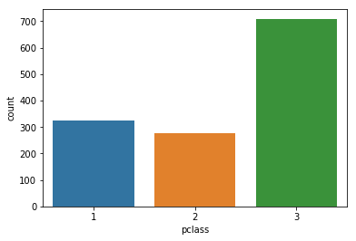

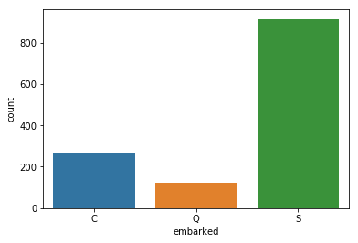

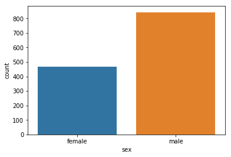

```python
import seaborn as sns
import matplotlib.pyplot as plt
%matplotlib inline

hist_attributes = ['pclass', 'embarked', 'sex']
for attr in hist_attributes:
    plt.figure();
    sns.countplot(df_titanic[attr])
    plt.show()
```

For the *age* category, we get rid of NaN values.

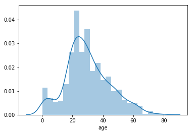

```python
sns.distplot(df_titanic['age'].dropna())
plt.show()
```

### 3. Calculate the proportion of passengers by *cabin floor*. Present your results in a *pie chart*.

We did not take into account the NaN values

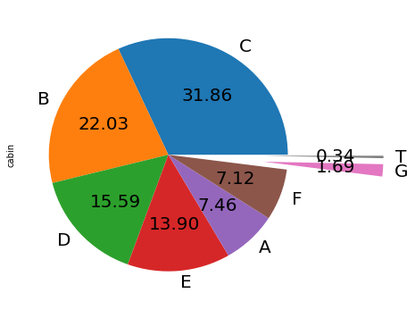

```python
# Fetch only the first letter of all the cabins id which is the floor
cabins = df_titanic['cabin']
floors = cabins.str[0]
floors.value_counts().plot.pie(autopct='%.2f', fontsize=20, figsize=(6, 6), explode = (0, 0, 0, 0, 0, 0, 0.8, 0.8))
```

### 4. For each *travel class*, calculate the proportion of the passengers that survived. Present your results in *pie charts*.

```
Class 1
```

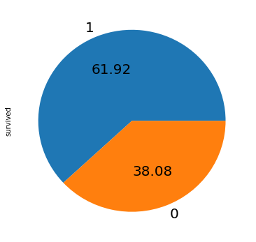

```
Class 2
```

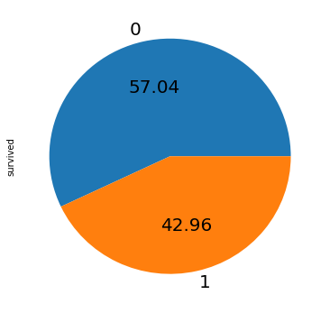

```
Class 3
```

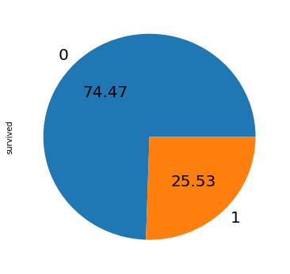

```python
# Create an array with all the classes
classes = df_titanic.pclass.unique()
for tr_class in classes:
    print('Class %s' % tr_class)
    cl_survived = df_titanic[df_titanic['pclass'] == tr_class].survived
    cl_survived.value_counts().plot.pie(autopct='%.2f', fontsize=20, figsize=(6, 6))
    plt.show()
    print('\n\n')
```

### 5. Calculate the proportion of the passengers that survived by *travel class* and *sex*. Present your results in *a single histogram*.

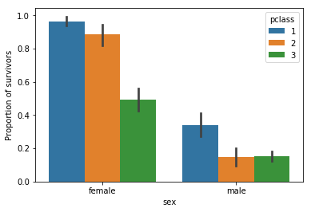

```python
df_titanic = pd.read_excel(DATA_FOLDER + '/titanic.xls')
ax = sns.barplot(x="sex", y="survived", hue="pclass", data=df_titanic)
ax.set_ylabel('Proportion of survivors')
plt.show()
```

### 6. Create 2 equally populated *age categories* and calculate survival proportions by *age category*, *travel class* and *sex*. Present your results in a `DataFrame` with unique index.

//TODO didnt get it...

```python
cat_age = pd.qcut(df_titanic.age, 2)
print(cat_age.values)
```

```
[(28, 80], [0.167, 28], [0.167, 28], (28, 80], [0.167, 28], ..., [0.167, 28], NaN, [0.167, 28], [0.167, 28], (28, 80]]
Length: 1309
Categories (2, object): [[0.167, 28] < (28, 80]]
```

```python
df_titanic = df_titanic.assign(cat_age=cat_age)
df_titanic.head()
```

|  | pclass | survived | name | sex | age | sibsp | parch | ticket | fare | cabin | embarked | boat | body | home.dest | cat_age |
| --- | --- | --- | --- | --- | --- | --- | --- | --- | --- | --- | --- | --- | --- | --- | --- |
| 0 | 1 | 1 | Allen, Miss. Elisabeth Walton | female | 29.0000 | 0 | 0 | 24160 | 211.3375 | B5 | S | 2 | NaN | St Louis, MO | (28, 80] |
| 1 | 1 | 1 | Allison, Master. Hudson Trevor | male | 0.9167 | 1 | 2 | 113781 | 151.5500 | C22 C26 | S | 11 | NaN | Montreal, PQ / Chesterville, ON | [0.167, 28] |
| 2 | 1 | 0 | Allison, Miss. Helen Loraine | female | 2.0000 | 1 | 2 | 113781 | 151.5500 | C22 C26 | S | NaN | NaN | Montreal, PQ / Chesterville, ON | [0.167, 28] |
| 3 | 1 | 0 | Allison, Mr. Hudson Joshua Creighton | male | 30.0000 | 1 | 2 | 113781 | 151.5500 | C22 C26 | S | NaN | 135.0 | Montreal, PQ / Chesterville, ON | (28, 80] |
| 4 | 1 | 0 | Allison, Mrs. Hudson J C (Bessie Waldo Daniels) | female | 25.0000 | 1 | 2 | 113781 | 151.5500 | C22 C26 | S | NaN | NaN | Montreal, PQ / Chesterville, ON | [0.167, 28] |

```python
overall_cat =df_titanic.cat_age.astype(str)+df_titanic.pclass.astype(str)+df_titanic.sex.astype(str)
```

```python
df_titanic_overall_cat = df_titanic.assign(overall_cat=overall_cat)
df_titanic_overall_cat.head()
```

|  | pclass | survived | name | sex | age | sibsp | parch | ticket | fare | cabin | embarked | boat | body | home.dest | cat_age | overall_cat |
| --- | --- | --- | --- | --- | --- | --- | --- | --- | --- | --- | --- | --- | --- | --- | --- | --- |
| 0 | 1 | 1 | Allen, Miss. Elisabeth Walton | female | 29.0000 | 0 | 0 | 24160 | 211.3375 | B5 | S | 2 | NaN | St Louis, MO | (28, 80] | (28, 80]1female |
| 1 | 1 | 1 | Allison, Master. Hudson Trevor | male | 0.9167 | 1 | 2 | 113781 | 151.5500 | C22 C26 | S | 11 | NaN | Montreal, PQ / Chesterville, ON | [0.167, 28] | [0.167, 28]1male |
| 2 | 1 | 0 | Allison, Miss. Helen Loraine | female | 2.0000 | 1 | 2 | 113781 | 151.5500 | C22 C26 | S | NaN | NaN | Montreal, PQ / Chesterville, ON | [0.167, 28] | [0.167, 28]1female |
| 3 | 1 | 0 | Allison, Mr. Hudson Joshua Creighton | male | 30.0000 | 1 | 2 | 113781 | 151.5500 | C22 C26 | S | NaN | 135.0 | Montreal, PQ / Chesterville, ON | (28, 80] | (28, 80]1male |
| 4 | 1 | 0 | Allison, Mrs. Hudson J C (Bessie Waldo Daniels) | female | 25.0000 | 1 | 2 | 113781 | 151.5500 | C22 C26 | S | NaN | NaN | Montreal, PQ / Chesterville, ON | [0.167, 28] | [0.167, 28]1female |

```python
# Fetch and sort the count for each category
counts = df_titanic_overall_cat.overall_cat.value_counts()
all_counts = counts.sort_index()

# Fetch and sort the count of survivors in those categories
survived_counts = df_titanic_overall_cat[df_titanic_overall_cat.survived == 1].overall_cat.value_counts()
survived_counts = survived_counts.sort_index()

# Compute the proportion and change the format of float number to 2 digits after comma
pd.options.display.float_format = '{:,.2f}'.format
df_titanic_prop = survived_counts.divide(all_counts).mul(100)

# Create the data frame to show results
ages = df_titanic.cat_age.unique().astype(str)
classes = df_titanic.pclass.unique()
sexes = df_titanic.sex.unique()
np.place(ages, ages == 'nan', 'unknown')
iterables = [ages, classes, sexes]
index = pd.MultiIndex.from_product(iterables, names=['age', 'class', 'sex'])
results = pd.Series(df_titanic_prop.values, index=index)
df_results = pd.DataFrame(results)
df_results.rename(columns={0: 'survival proportion in %'})
```

| age | class | sex | survival proportion in % |
| --- | --- | --- | --- |
| (28, 80] | 1 | female | 96.74 |
|  |  | male | 30.25 |
|  | 2 | female | 87.23 |
|  |  | male | 8.33 |
|  | 3 | female | 37.21 |
|  |  | male | 14.40 |
| [0.167, 28] | 1 | female | 95.12 |
|  |  | male | 53.12 |
|  | 2 | female | 91.07 |
|  |  | male | 21.62 |
|  | 3 | female | 51.38 |
|  |  | male | 18.30 |
| unknown | 1 | female | 100.00 |
|  |  | male | 28.57 |
|  | 2 | female | 66.67 |
|  |  | male | 15.38 |
|  | 3 | female | 53.12 |
|  |  | male | 11.11 |